# Holiday_package_prediction_Milestone1

- 1. Table of Contents
- 1. Introduction
     - 2.1 Dataset Description
     - 2.2 Objective
- 1. Import Library
- 1. Data Loading
     - 4.1 Dataset Exploration
- 1. Data Cleaning
     - 5.1 Missing Values
     - 5.2 Duplicate Values
- 1. Data Exploration (EDA)
     - 6.1 Univariate
     - 6.2 Bivariate
     - 6.3 Multivariate
     - 6.4 Target Variable
- 1. Data Preprocessing
     - 7.1 Replace Category
     - 7.2 Handling Outlier Values
     - 7.3 Feature Selection
     - 7.4 Feature Encoding
     - 7.5 Split Dataset
     - 7.6 Feature Scaling
     - 7.7 Handling Imbalance Data
- 1. Tuning with Grid Search CV
     - 8.1 Logistic Regression
     - 8.2 Decision Tress
     - 8.3 Random Forest
     - 8.4 K-Nearest Neighbors
     - 8.5 Adaboost
     - 8.6 XGBoost
- 1. Define Model
- 1. Model Training
     - 10.1 Faeture Importance
     - 10.2 Cross Validation Score
- 1. Model Evaluation
     - 11.1 Confusion Matrix
     - 11.2 Evaluation
     - 11.3 Shap Value XGBoost
- 1. Conlusion
     - 12.1 Insights From EDA
     - 12.2 Model Analysis

# Introduction

- Batch: 18 Data Science
- Final Project Rakamin Academy
- Members of the group:
  - Aisyah Khairunnisa A
  - Budi Dwi Ananto
  - David Prayogo
  - Gayatri Ayodhya
  - Hafidh Rizky
  - Muharlan
  - Shafa Amelia
  - Sony Monthona R K

## Dataset Description

This data is offer data on holiday packages originating from a travel company and plans to expand its business through the latest package offerings, namely the Wellness Tourism Package with the target of whether the holiday package is taken or not(ProdTaken).

Source: ML Repo > [Holiday_Package_Prediction](https://www.kaggle.com/datasets/susant4learning/holiday-package-purchase-prediction)

| Columns | Description | Type |
| --- | --- | --- |
| CustomerID | Unique customers ID |  |
| ProdTaken | does the customers take a vacation package? (0: No, 1: Yes) | Target Variable |
| Age | Age of customer | Numeric |
| TypeofContact | How customer was contacted (Company Invited or Self Inquiry) | Categorical |
| CityTier | City tier depends on the development of a city, population, facilities, and living standards. The categories are ordered i.e. | Categorical |
| DurationOfPitch | Duration of the pitch by a salesperson to the customer | Numeric |
| Occupation | Occupation of customer | Categorical |
| Gender | Gender of customer | Categorical |
| NumberOfPersonVisiting | Total number of persons planning to take the trip with the customer | Numeric |
| NumberOfFollowups | Total number of follow-ups has been done by the salesperson after the sales pitch | Numeric |
| ProductPitched | Product pitched by the salesperson | Categorical |
| PreferredPropertyStar | Preferred hotel property rating by customer | Categorical |
| MaritalStatus | Marital status of customer | Categorical |
| NumberOfTrips | Average number of trips in a year by customer | Numeric |
| Passport | The customer has a passport or not (0: No, 1: Yes) | Boolean |
| PitchSatisfactionScore | Sales pitch satisfaction score | Categorical |
| OwnCar | Whether the customers own a car or not (0: No, 1: Yes) | Boolean |
| NumberOfChildrenVisiting | Total number of children with age less than 5 planning to take the trip with the customer | Numeric |
| Designation | Designation of the customer in the current organization | Categorical |
| MonthlyIncome | Gross monthly income of the customer | Numeric |

## Objective

Create a model for predict users who have the potential to buy Wellness Tourism Package.

1. Compare the performance between each algorithm as follows:
   - Logistic Regression,
   - Decision Tree,
   - Random Forest,
   - K-Nearest Neighbors,
   - AdaBoost,
   - XGBoost.
2. Decide which algorithm that we will use based on the best performance on the chosen metrics.
3. Percentage of users who bought vacation packages.
4. Analyze what kind of customers are more likely to take vacation packages.

# Import Library

```python
import pandas as pd
import numpy as np
import matplotlib.pyplot as plt
import seaborn as sns
from scipy import stats
from matplotlib import rcParams
import time
import warnings
warnings.filterwarnings('ignore')
```

```python
import sklearn
sklearn.__version__
```

```
'1.0.2'
```

```python
from sklearn.model_selection import train_test_split
from sklearn.preprocessing import StandardScaler
from imblearn import under_sampling, over_sampling
from sklearn.metrics import accuracy_score, precision_score, recall_score, f1_score, roc_auc_score, auc
from sklearn.metrics import plot_confusion_matrix, confusion_matrix, classification_report
from sklearn.model_selection import train_test_split, cross_val_score, GridSearchCV

from sklearn.linear_model import LogisticRegression
from sklearn.tree import DecisionTreeClassifier
from sklearn.ensemble import RandomForestClassifier
from sklearn.neighbors import KNeighborsClassifier
from sklearn.ensemble import AdaBoostClassifier
from xgboost import XGBClassifier
import xgboost as xgb

from scipy.stats import uniform
import shap
```

# Data Loading

Loading dataset into df dataframe

```python
df = pd.read_csv('Travel.csv')
```

## Dataset Exploration

```python
df.tail()
```

|  | CustomerID | ProdTaken | Age | TypeofContact | CityTier | DurationOfPitch | Occupation | Gender | NumberOfPersonVisiting | NumberOfFollowups | ProductPitched | PreferredPropertyStar | MaritalStatus | NumberOfTrips | Passport | PitchSatisfactionScore | OwnCar | NumberOfChildrenVisiting | Designation | MonthlyIncome |
| --- | --- | --- | --- | --- | --- | --- | --- | --- | --- | --- | --- | --- | --- | --- | --- | --- | --- | --- | --- | --- |
| 4883 | 204883 | 1 | 49.0 | Self Enquiry | 3 | 9.0 | Small Business | Male | 3 | 5.0 | Deluxe | 4.0 | Unmarried | 2.0 | 1 | 1 | 1 | 1.0 | Manager | 26576.0 |
| 4884 | 204884 | 1 | 28.0 | Company Invited | 1 | 31.0 | Salaried | Male | 4 | 5.0 | Basic | 3.0 | Single | 3.0 | 1 | 3 | 1 | 2.0 | Executive | 21212.0 |
| 4885 | 204885 | 1 | 52.0 | Self Enquiry | 3 | 17.0 | Salaried | Female | 4 | 4.0 | Standard | 4.0 | Married | 7.0 | 0 | 1 | 1 | 3.0 | Senior Manager | 31820.0 |
| 4886 | 204886 | 1 | 19.0 | Self Enquiry | 3 | 16.0 | Small Business | Male | 3 | 4.0 | Basic | 3.0 | Single | 3.0 | 0 | 5 | 0 | 2.0 | Executive | 20289.0 |
| 4887 | 204887 | 1 | 36.0 | Self Enquiry | 1 | 14.0 | Salaried | Male | 4 | 4.0 | Basic | 4.0 | Unmarried | 3.0 | 1 | 3 | 1 | 2.0 | Executive | 24041.0 |

```python
df.head()
```

|  | CustomerID | ProdTaken | Age | TypeofContact | CityTier | DurationOfPitch | Occupation | Gender | NumberOfPersonVisiting | NumberOfFollowups | ProductPitched | PreferredPropertyStar | MaritalStatus | NumberOfTrips | Passport | PitchSatisfactionScore | OwnCar | NumberOfChildrenVisiting | Designation | MonthlyIncome |
| --- | --- | --- | --- | --- | --- | --- | --- | --- | --- | --- | --- | --- | --- | --- | --- | --- | --- | --- | --- | --- |
| 0 | 200000 | 1 | 41.0 | Self Enquiry | 3 | 6.0 | Salaried | Female | 3 | 3.0 | Deluxe | 3.0 | Single | 1.0 | 1 | 2 | 1 | 0.0 | Manager | 20993.0 |
| 1 | 200001 | 0 | 49.0 | Company Invited | 1 | 14.0 | Salaried | Male | 3 | 4.0 | Deluxe | 4.0 | Divorced | 2.0 | 0 | 3 | 1 | 2.0 | Manager | 20130.0 |
| 2 | 200002 | 1 | 37.0 | Self Enquiry | 1 | 8.0 | Free Lancer | Male | 3 | 4.0 | Basic | 3.0 | Single | 7.0 | 1 | 3 | 0 | 0.0 | Executive | 17090.0 |
| 3 | 200003 | 0 | 33.0 | Company Invited | 1 | 9.0 | Salaried | Female | 2 | 3.0 | Basic | 3.0 | Divorced | 2.0 | 1 | 5 | 1 | 1.0 | Executive | 17909.0 |
| 4 | 200004 | 0 | NaN | Self Enquiry | 1 | 8.0 | Small Business | Male | 2 | 3.0 | Basic | 4.0 | Divorced | 1.0 | 0 | 5 | 1 | 0.0 | Executive | 18468.0 |

```python
print(f"Rows, Cols: {df.shape[0], df.shape[1]}")
df.info()
```

```
Rows, Cols: (4888, 20)
<class 'pandas.core.frame.DataFrame'>
RangeIndex: 4888 entries, 0 to 4887
Data columns (total 20 columns):
 #   Column                    Non-Null Count  Dtype
---  ------                    --------------  -----
 0   CustomerID                4888 non-null   int64
 1   ProdTaken                 4888 non-null   int64
 2   Age                       4662 non-null   float64
 3   TypeofContact             4863 non-null   object
 4   CityTier                  4888 non-null   int64
 5   DurationOfPitch           4637 non-null   float64
 6   Occupation                4888 non-null   object
 7   Gender                    4888 non-null   object
 8   NumberOfPersonVisiting    4888 non-null   int64
 9   NumberOfFollowups         4843 non-null   float64
 10  ProductPitched            4888 non-null   object
 11  PreferredPropertyStar     4862 non-null   float64
 12  MaritalStatus             4888 non-null   object
 13  NumberOfTrips             4748 non-null   float64
 14  Passport                  4888 non-null   int64
 15  PitchSatisfactionScore    4888 non-null   int64
 16  OwnCar                    4888 non-null   int64
 17  NumberOfChildrenVisiting  4822 non-null   float64
 18  Designation               4888 non-null   object
 19  MonthlyIncome             4655 non-null   float64
dtypes: float64(7), int64(7), object(6)
memory usage: 763.9+ KB
```

- This dataset contains 4K (4888) rows and 20 columns. Amongst the columns, we have the target variable which is named 'ProdTaken'.
- This dataset is a mix of numerical and categorical variables.
- The target variable is in categorical data type and it's already converted to boolean type.

```python
num_cols = list(df.select_dtypes("number").columns)
print(num_cols)
```

```
['CustomerID', 'ProdTaken', 'Age', 'CityTier', 'DurationOfPitch', 'NumberOfPersonVisiting', 'NumberOfFollowups', 'PreferredPropertyStar', 'NumberOfTrips', 'Passport', 'PitchSatisfactionScore', 'OwnCar', 'NumberOfChildrenVisiting', 'MonthlyIncome']
```

These are the descriptive statistics of the numerical variable in the dataset.

```python
df.select_dtypes("number").describe().T
```

|  | count | mean | std | min | 25% | 50% | 75% | max |
| --- | --- | --- | --- | --- | --- | --- | --- | --- |
| CustomerID | 4888.0 | 202443.500000 | 1411.188388 | 200000.0 | 201221.75 | 202443.5 | 203665.25 | 204887.0 |
| ProdTaken | 4888.0 | 0.188216 | 0.390925 | 0.0 | 0.00 | 0.0 | 0.00 | 1.0 |
| Age | 4662.0 | 37.622265 | 9.316387 | 18.0 | 31.00 | 36.0 | 44.00 | 61.0 |
| CityTier | 4888.0 | 1.654255 | 0.916583 | 1.0 | 1.00 | 1.0 | 3.00 | 3.0 |
| DurationOfPitch | 4637.0 | 15.490835 | 8.519643 | 5.0 | 9.00 | 13.0 | 20.00 | 127.0 |
| NumberOfPersonVisiting | 4888.0 | 2.905074 | 0.724891 | 1.0 | 2.00 | 3.0 | 3.00 | 5.0 |
| NumberOfFollowups | 4843.0 | 3.708445 | 1.002509 | 1.0 | 3.00 | 4.0 | 4.00 | 6.0 |
| PreferredPropertyStar | 4862.0 | 3.581037 | 0.798009 | 3.0 | 3.00 | 3.0 | 4.00 | 5.0 |
| NumberOfTrips | 4748.0 | 3.236521 | 1.849019 | 1.0 | 2.00 | 3.0 | 4.00 | 22.0 |
| Passport | 4888.0 | 0.290917 | 0.454232 | 0.0 | 0.00 | 0.0 | 1.00 | 1.0 |
| PitchSatisfactionScore | 4888.0 | 3.078151 | 1.365792 | 1.0 | 2.00 | 3.0 | 4.00 | 5.0 |
| OwnCar | 4888.0 | 0.620295 | 0.485363 | 0.0 | 0.00 | 1.0 | 1.00 | 1.0 |
| NumberOfChildrenVisiting | 4822.0 | 1.187267 | 0.857861 | 0.0 | 1.00 | 1.0 | 2.00 | 3.0 |
| MonthlyIncome | 4655.0 | 23619.853491 | 5380.698361 | 1000.0 | 20346.00 | 22347.0 | 25571.00 | 98678.0 |

General observations:

```python
cat_cols = list(df.select_dtypes(object).columns)
print(cat_cols)
```

```
['TypeofContact', 'Occupation', 'Gender', 'ProductPitched', 'MaritalStatus', 'Designation']
```

```python
for col in cat_cols:
    print(f'''Value count kolom {col}:''')
    print(df[col].value_counts())
    print()
```

```
Value count kolom TypeofContact:
Self Enquiry       3444
Company Invited    1419
Name: TypeofContact, dtype: int64

Value count kolom Occupation:
Salaried          2368
Small Business    2084
Large Business     434
Free Lancer          2
Name: Occupation, dtype: int64

Value count kolom Gender:
Male       2916
Female     1817
Fe Male     155
Name: Gender, dtype: int64

Value count kolom ProductPitched:
Basic           1842
Deluxe          1732
Standard         742
Super Deluxe     342
King             230
Name: ProductPitched, dtype: int64

Value count kolom MaritalStatus:
Married      2340
Divorced      950
Single        916
Unmarried     682
Name: MaritalStatus, dtype: int64

Value count kolom Designation:
Executive         1842
Manager           1732
Senior Manager     742
AVP                342
VP                 230
Name: Designation, dtype: int64
```

```python
df.select_dtypes(object).describe().T
```

|  | count | unique | top | freq |
| --- | --- | --- | --- | --- |
| TypeofContact | 4863 | 2 | Self Enquiry | 3444 |
| Occupation | 4888 | 4 | Salaried | 2368 |
| Gender | 4888 | 3 | Male | 2916 |
| ProductPitched | 4888 | 5 | Basic | 1842 |
| MaritalStatus | 4888 | 4 | Married | 2340 |
| Designation | 4888 | 5 | Executive | 1842 |

All of the categorical variable has values that have low cardinality (less unique value). The cardinality of the categorical variable is needed to be check because we don't want the model to consume a lot of time in running the algorithm its time complexity is affected by the number of features.

# Data Cleaning

## Missing Values

```python
df.isnull().any()
```

```
CustomerID                  False
ProdTaken                   False
Age                          True
TypeofContact                True
CityTier                    False
DurationOfPitch              True
Occupation                  False
Gender                      False
NumberOfPersonVisiting      False
NumberOfFollowups            True
ProductPitched              False
PreferredPropertyStar        True
MaritalStatus               False
NumberOfTrips                True
Passport                    False
PitchSatisfactionScore      False
OwnCar                      False
NumberOfChildrenVisiting     True
Designation                 False
MonthlyIncome                True
dtype: bool
```

```python
percent_missing = df.isnull().sum() * 100 / len(df)
percent_missing
```

```
CustomerID                  0.000000
ProdTaken                   0.000000
Age                         4.623568
TypeofContact               0.511457
CityTier                    0.000000
DurationOfPitch             5.135025
Occupation                  0.000000
Gender                      0.000000
NumberOfPersonVisiting      0.000000
NumberOfFollowups           0.920622
ProductPitched              0.000000
PreferredPropertyStar       0.531915
MaritalStatus               0.000000
NumberOfTrips               2.864157
Passport                    0.000000
PitchSatisfactionScore      0.000000
OwnCar                      0.000000
NumberOfChildrenVisiting    1.350245
Designation                 0.000000
MonthlyIncome               4.766776
dtype: float64
```

- The shape of df before dropping the missing rows:

```python
print(f"Rows, Cols - Before: {df.shape[0], df.shape[1]}")
```

```
Rows, Cols - Before: (4888, 20)
```

- Drop missing value on variables TypeofContact, NumberOfFollowups, PreferredPropertyStar and NumberOfChildrenVisiting because the number of missing values is still small

```python
df = df.dropna(subset=['TypeofContact','NumberOfFollowups','PreferredPropertyStar','NumberOfChildrenVisiting' ])
```

- Fill in the missing values in the 'Age' column with the mean because the distribution is close to normal, and fill in the median value for the 'MonthlyIncome' and 'DurationOfPitch' column because the skews are positive.

```python
df['Age'].fillna(df['Age'].mean(), inplace=True)
df['MonthlyIncome'].fillna(df['MonthlyIncome'].median(), inplace=True)
df['DurationOfPitch'].fillna(df['DurationOfPitch'].median(), inplace=True)
```

- Fill in the missing values in the 'Number Of Trips' column with a mode value of 2

```python
df['NumberOfTrips'].fillna(df['NumberOfTrips'].mode()[0], inplace=True)
```

The shape of df after dropping the missing rows:

```python
print(f"Rows, Cols - After: {df.shape[0], df.shape[1]}")
```

```
Rows, Cols - After: (4726, 20)
```

## Duplicate Values

```python
df.duplicated().any()
```

```
False
```

This dataset doesn't contain duplicate values of all columns.

# Data Exploration (EDA)

```python
num_cols = list(df.select_dtypes("number").columns)
print("Num Features Length",len(num_cols), ":", num_cols)
```

```
Num Features Length 14 : ['CustomerID', 'ProdTaken', 'Age', 'CityTier', 'DurationOfPitch', 'NumberOfPersonVisiting', 'NumberOfFollowups', 'PreferredPropertyStar', 'NumberOfTrips', 'Passport', 'PitchSatisfactionScore', 'OwnCar', 'NumberOfChildrenVisiting', 'MonthlyIncome']
```

We have 14 numerical features in the dataset.

## Univariate

```python
num_cols_skewness = df[num_cols].skew()
```

If skewness is less than -1 or greater than 1, the distribution is highly skewed. If skewness is between -1 and -0.5 or between 0.5 and 1, the distribution is moderately skewed. If skewness is between -0.5 and 0.5, the distribution is approximately symmetric.

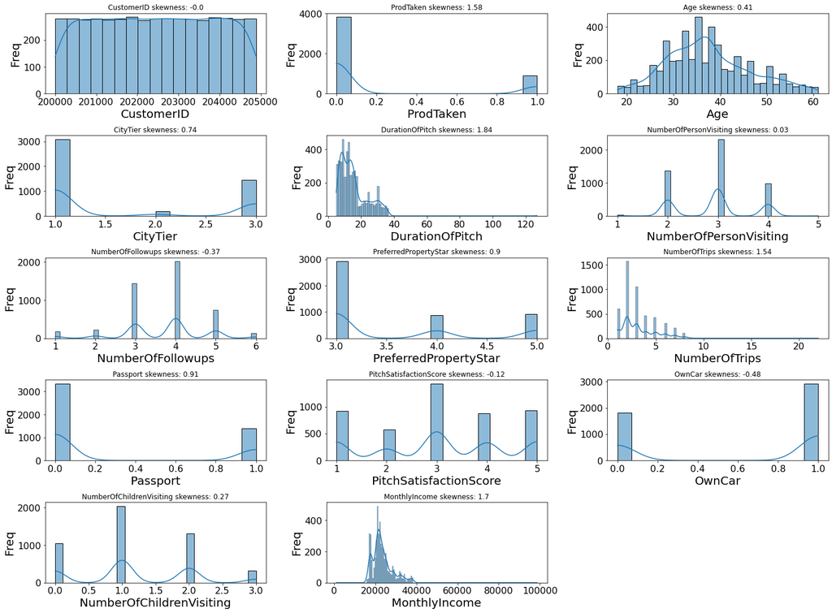

```python
plt.figure(figsize=(20, 20))
for i in range(len(num_cols)):
    plt.subplot(len(num_cols)//2, 3, i+1)
    ax = sns.histplot(
        df[num_cols[i]],
        kde = True
    )
    ax.set_xlabel(str(num_cols[i]), fontsize = 20)
    ax.set_ylabel("Freq", fontsize = 20)
    ax.tick_params(labelsize=16)
    ax.set_title(str(num_cols[i]) + ' skewness: ' + str(round(num_cols_skewness[i], 2)))
plt.tight_layout()
plt.savefig('num histplot.png', bbox_inches = 'tight', dpi = 300, transparent = True)
plt.show()
```

General observation:

- Column 'Age' has a distribution that is close to normal or symmetrical, it can be seen from the picture and the skew value is close to 0.5 (0.41).
- Columns 'DurationOfPitch' and 'MonthlyIncome' have a positive skew (skew to the right) i.e. more concentrated on the left and a long tail on the right side, the skew results also show their respective values are 1.84 and 1.7, respectively.
- The 'MonthlyIncome' column allows for normalization because the variation in income is quite large for the numerical column with range variation is large.
- Other columns are not given much attention because among them are ordinal and nominal type columns whose format is made in numeric form so that it still needs to be done at the preprocessing stage for Feature Encoding.

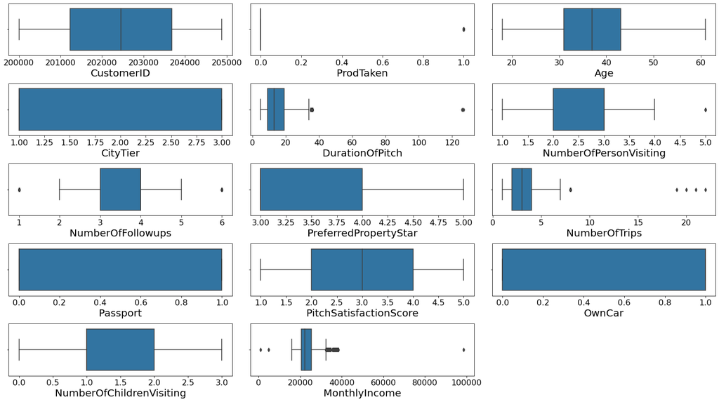

```python
plt.figure(figsize=(20, 15))
for i in range(len(num_cols)):
    plt.subplot(len(num_cols)//2, 3, i+1)
    ax = sns.boxplot(
        x = df[num_cols[i]]
    )
    ax.set_xlabel(str(num_cols[i]), fontsize = 20)
    ax.tick_params(labelsize=16)
plt.tight_layout()
plt.savefig('num boxplot.png', bbox_inches = 'tight', dpi = 300, transparent = True)
plt.show()
```

Features that contains outliers:

On the upper limits:

- DurationOfPitch, NumberOfPersonVisiting, and NumberOfTrips.

Below the bottom and upper limits:

- NumberOfFollowups and MonthlyIncome

```python
cat_cols = list(df.select_dtypes(object).columns)
print(cat_cols)
```

```
['TypeofContact', 'Occupation', 'Gender', 'ProductPitched', 'MaritalStatus', 'Designation']
```

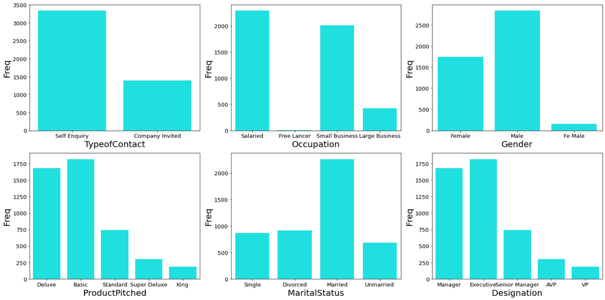

```python
plt.figure(figsize=(20, 10))
for i in range(0, len(cat_cols)):
    plt.subplot(2, 3, i+1)
    ax = sns.countplot(x = df[cat_cols[i]], color='Cyan', orient='v')
    ax.set_xlabel(str(cat_cols[i]), fontsize = 20)
    ax.tick_params(labelsize=13)
    ax.set_ylabel("Freq", fontsize = 20)
    plt.tight_layout()
plt.savefig("univariat plot.jpg", dpi=150)
```

Observation results:

- The Self Inquiry category of the 'TypeofContact' column has more proportion than the Company Invited category.
- In the 'Occupation' column, most users come from the Salaried category, while in the Free Lancer category there are almost none.
- Users in the 'Gender' column are dominated by Male.
- In the 'ProductPitched' column the most categories are Basic, then the number is decreasing in the Deluxe to King categories.
- In the 'MaritalStatus' column, the number of users in the Married category is the most compared to other categories.
- Users who are included in the Executive category in the 'Designation' column ranks the most followed by the Manager, Senior Manager, AVP, and VP categories.

## Bivariate

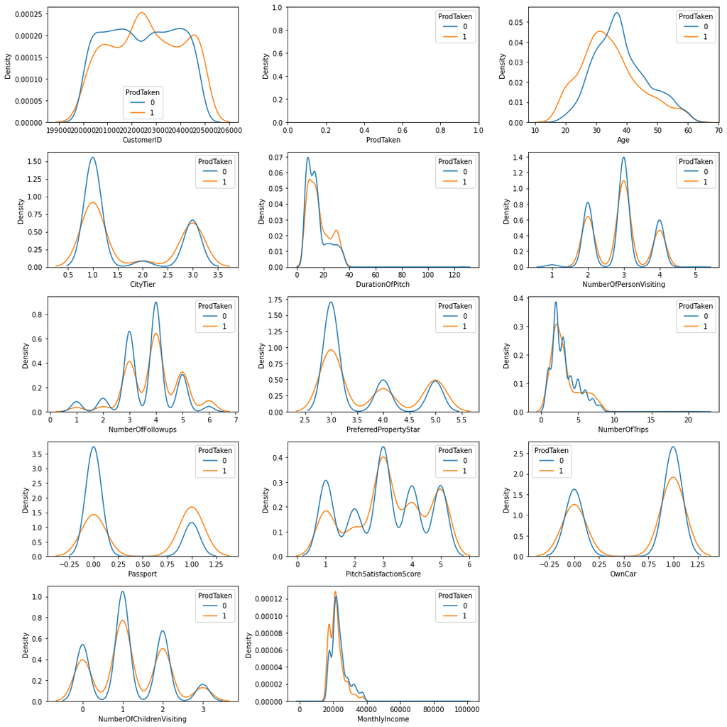

```python
features = num_cols
plt.figure(figsize=(15, 15))
for i in range(0, len(num_cols)):
    plt.subplot(5, len(num_cols)/4, i+1)
    sns.kdeplot(x=df[features[i]], hue=df['ProdTaken'], common_norm=False, palette=["C0", "C1"])
    plt.xlabel(features[i])
    plt.tight_layout()
plt.savefig("numerik plot.jpg", dpi=150)
```

The age distribution of customers who pick up or no pick up the package has almost the same symmetric distribution. While the duration of the sales force making offers there is also no significant difference of the distribution, which is symmetrical to the right. It same for the monthly income column, the slope distribution is more symmetrical to the right for customers who take the package or not

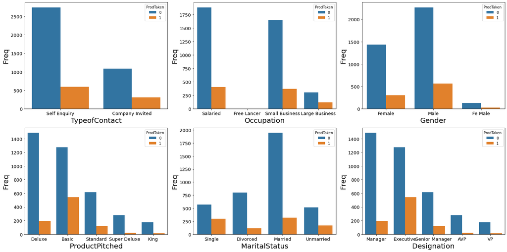

```python
plt.figure(figsize=(20, 10))
for i in range(0, len(cat_cols)):
    plt.subplot(2, 3, i+1)
    ax = sns.countplot(x = df[cat_cols[i]], hue=df['ProdTaken'], palette=["C0", "C1"], orient='v')
    ax.set_xlabel(str(cat_cols[i]), fontsize = 20)
    ax.tick_params(labelsize=13)
    ax.set_ylabel("Freq", fontsize = 20)
    plt.tight_layout()
plt.savefig("count plot.jpg", dpi=150)
```

- The result of the frequency that has more customers do not take vacation packages, this is in accordance with the problem statement which explains that only 18% of customers take vacation packages for offers that are made randomly so that it is not appropriate in marketing.
- However, the type of customer contact in making an offer with a larger ratio is the company invited
- Type of work type has a higher ratio in large businesses
- Type of product has a higher ratio than the basic product
- and a larger designation ratio in executive positions

```python
df.groupby(["ProdTaken"]).median()
```

| ProdTaken | CustomerID | Age | CityTier | DurationOfPitch | NumberOfPersonVisiting | NumberOfFollowups | PreferredPropertyStar | NumberOfTrips | Passport | PitchSatisfactionScore | OwnCar | NumberOfChildrenVisiting | MonthlyIncome |
| --- | --- | --- | --- | --- | --- | --- | --- | --- | --- | --- | --- | --- | --- |
| 0 | 202448.5 | 37.0 | 1.0 | 13.0 | 3.0 | 4.0 | 3.0 | 3.0 | 0.0 | 3.0 | 1.0 | 1.0 | 22379.0 |
| 1 | 202461.5 | 33.0 | 1.0 | 15.0 | 3.0 | 4.0 | 3.0 | 3.0 | 1.0 | 3.0 | 1.0 | 1.0 | 21242.0 |

```python
df.groupby(['ProdTaken']).agg({
    'Age':['median','mean','max', 'min',np.ptp, 'std',lambda x: np.percentile(x, q=25),lambda x: np.percentile(x, q=75)],
    'DurationOfPitch':['median','mean','max', 'min',np.ptp, 'std',lambda x: np.percentile(x, q=25),lambda x: np.percentile(x, q=75)]
})
```

| ProdTaken | Age median | Age mean | Age max | Age min | Age ptp | Age std | Age <lambda_0> | Age <lambda_1> | DurationOfPitch median | DurationOfPitch mean | DurationOfPitch max | DurationOfPitch min | DurationOfPitch ptp | DurationOfPitch std | DurationOfPitch <lambda_0> | DurationOfPitch <lambda_1> |
| --- | --- | --- | --- | --- | --- | --- | --- | --- | --- | --- | --- | --- | --- | --- | --- | --- |
| 0 | 37.0 | 38.112485 | 61.0 | 18.0 | 43.0 | 8.723693 | 32.0 | 43.0 | 13.0 | 15.095039 | 127.0 | 5.0 | 122.0 | 8.330804 | 9.0 | 18.0 |
| 1 | 33.0 | 34.615826 | 60.0 | 18.0 | 42.0 | 9.609107 | 28.0 | 40.0 | 15.0 | 16.689732 | 36.0 | 6.0 | 30.0 | 8.275544 | 10.0 | 23.0 |

```python
df.groupby(['ProdTaken']).agg({
    'MonthlyIncome':['median','mean','max', 'min',np.ptp, 'std',lambda x: np.percentile(x, q=25),lambda x: np.percentile(x, q=75)],
    'NumberOfTrips':['median','mean','max', 'min',np.ptp, 'std',lambda x: np.percentile(x, q=25),lambda x: np.percentile(x, q=75)]
})
```

| ProdTaken | MonthlyIncome median | MonthlyIncome mean | MonthlyIncome max | MonthlyIncome min | MonthlyIncome ptp | MonthlyIncome std | MonthlyIncome <lambda_0> | MonthlyIncome <lambda_1> | NumberOfTrips median | NumberOfTrips mean | NumberOfTrips max | NumberOfTrips min | NumberOfTrips ptp | NumberOfTrips std | NumberOfTrips <lambda_0> | NumberOfTrips <lambda_1> |
| --- | --- | --- | --- | --- | --- | --- | --- | --- | --- | --- | --- | --- | --- | --- | --- | --- |
| 0 | 22379.0 | 23658.157702 | 98678.0 | 1000.0 | 97678.0 | 5020.041496 | 20766.0 | 25511.0 | 3.0 | 3.167363 | 22.0 | 1.0 | 21.0 | 1.778820 | 2.0 | 4.0 |
| 1 | 21242.0 | 21987.202009 | 38223.0 | 16009.0 | 22214.0 | 4277.925969 | 18408.0 | 23641.0 | 3.0 | 3.277902 | 20.0 | 1.0 | 19.0 | 2.040321 | 2.0 | 4.0 |

## Multivariate

```python
df.corr()
```

|  | CustomerID | ProdTaken | Age | CityTier | DurationOfPitch | NumberOfPersonVisiting | NumberOfFollowups | PreferredPropertyStar | NumberOfTrips | Passport | PitchSatisfactionScore | OwnCar | NumberOfChildrenVisiting | MonthlyIncome |
| --- | --- | --- | --- | --- | --- | --- | --- | --- | --- | --- | --- | --- | --- | --- |
| CustomerID | 1.000000 | 0.057767 | 0.022005 | 0.016182 | 0.072054 | 0.603481 | 0.429584 | 0.012076 | 0.200446 | 0.006661 | -0.038613 | 0.000662 | 0.509984 | 0.283919 |
| ProdTaken | 0.057767 | 1.000000 | -0.152268 | 0.088182 | 0.074931 | 0.008655 | 0.114014 | 0.097975 | 0.023659 | 0.262943 | 0.056617 | -0.013363 | 0.006892 | -0.132834 |
| Age | 0.022005 | -0.152268 | 1.000000 | -0.016065 | -0.007495 | 0.002140 | -0.011799 | -0.023979 | 0.142635 | 0.026714 | 0.011662 | 0.040696 | -0.003024 | 0.446919 |
| CityTier | 0.016182 | 0.088182 | -0.016065 | 1.000000 | 0.016035 | 0.004335 | 0.025312 | -0.014180 | -0.022117 | 0.002958 | -0.044302 | 0.007941 | 0.004591 | 0.062803 |
| DurationOfPitch | 0.072054 | 0.074931 | -0.007495 | 0.016035 | 1.000000 | 0.070594 | 0.019785 | -0.008160 | 0.014146 | 0.033941 | -0.004298 | 0.003906 | 0.038209 | 0.006669 |
| NumberOfPersonVisiting | 0.603481 | 0.008655 | 0.002140 | 0.004335 | 0.070594 | 1.000000 | 0.330540 | 0.035607 | 0.177606 | 0.006749 | -0.019816 | 0.009737 | 0.609436 | 0.196058 |
| NumberOfFollowups | 0.429584 | 0.114014 | -0.011799 | 0.025312 | 0.019785 | 0.330540 | 1.000000 | -0.024634 | 0.134551 | 0.008060 | -0.000493 | 0.005913 | 0.287640 | 0.172811 |
| PreferredPropertyStar | 0.012076 | 0.097975 | -0.023979 | -0.014180 | -0.008160 | 0.035607 | -0.024634 | 1.000000 | 0.011906 | 0.000023 | -0.021252 | 0.016117 | 0.036901 | 0.004597 |
| NumberOfTrips | 0.200446 | 0.023659 | 0.142635 | -0.022117 | 0.014146 | 0.177606 | 0.134551 | 0.011906 | 1.000000 | 0.008273 | -0.005351 | -0.014816 | 0.149304 | 0.057596 |
| Passport | 0.006661 | 0.262943 | 0.026714 | 0.002958 | 0.033941 | 0.006749 | 0.008060 | 0.000023 | 0.008273 | 1.000000 | -0.000912 | -0.023615 | 0.018197 | 0.000026 |
| PitchSatisfactionScore | -0.038613 | 0.056617 | 0.011662 | -0.044302 | -0.004298 | -0.019816 | -0.000493 | -0.021252 | -0.005351 | -0.000912 | 1.000000 | 0.068061 | -0.001224 | 0.021156 |
| OwnCar | 0.000662 | -0.013363 | 0.040696 | 0.007941 | 0.003906 | 0.009737 | 0.005913 | 0.016117 | -0.014816 | -0.023615 | 0.068061 | 1.000000 | 0.023044 | 0.067110 |
| NumberOfChildrenVisiting | 0.509984 | 0.006892 | -0.003024 | 0.004591 | 0.038209 | 0.609436 | 0.287640 | 0.036901 | 0.149304 | 0.018197 | -0.001224 | 0.023044 | 1.000000 | 0.201964 |
| MonthlyIncome | 0.283919 | -0.132834 | 0.446919 | 0.062803 | 0.006669 | 0.196058 | 0.172811 | 0.004597 | 0.057596 | 0.000026 | 0.021156 | 0.067110 | 0.201964 | 1.000000 |

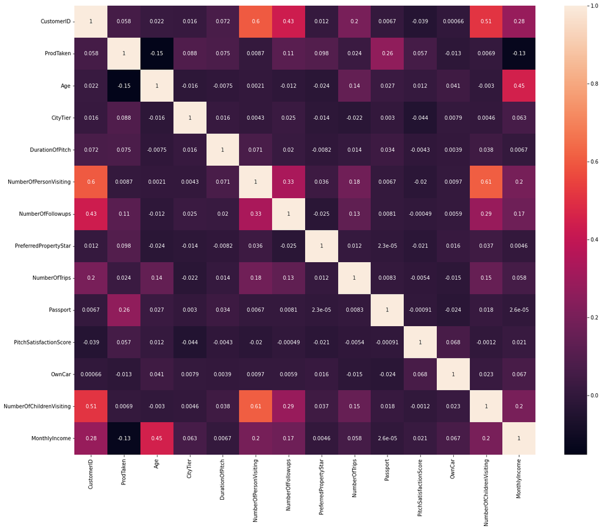

```python
plt.figure(figsize=(20,16))
svm = sns.heatmap(df.corr(),annot=True)
plt.show()
figure = svm.get_figure()
figure.savefig("heatmap.jpg", dpi=150)
```

## Target Variable

```python
df.groupby(["ProdTaken"]).count()[["CustomerID"]].rename({"CustomerID" : "nunique"}, axis = 1)
```

| ProdTaken | nunique |
| --- | --- |
| 0 | 3830 |
| 1 | 896 |

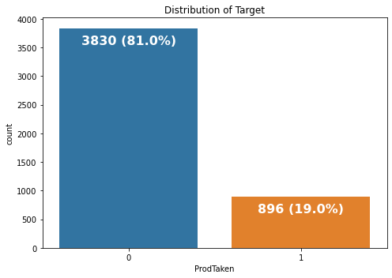

```python
plt.figure(figsize = (7, 5))
ax = sns.countplot(
    x = df["ProdTaken"],
)
ax.set_title("Distribution of Target")
# annotate bar
for p in ax.patches:
    ax.annotate(
        format(p.get_height(), '.0f') + " (" + format(p.get_height()*100/len(df), '.1f') + "%)",
        (p.get_x() + p.get_width() / 2., p.get_height()),
        ha = 'center',
        fontweight = 'semibold',
        size = 16,
        xytext = (0, -20),
        textcoords = 'offset points',
        color = 'white'
    )
plt.tight_layout()
plt.show()
```

# Data Preprocessing

## Replace Category

- Change "fe male" to "female"

```python
df['Gender'] = df['Gender'].astype('category')
df['Gender'] = df['Gender'].cat.rename_categories({'Fe Male': 'female'})
df['Gender'] = df['Gender'].str.lower()
df['Gender'].value_counts()
```

```
male      2833
female    1893
Name: Gender, dtype: int64
```

- Merge single and unmarried into single

```python
df['MaritalStatus'] = df['MaritalStatus'].apply(lambda x: x.replace("Unmarried", "Single"))
df['MaritalStatus'].value_counts()
```

```
Married     2263
Single      1547
Divorced     916
Name: MaritalStatus, dtype: int64
```

## Handling Outlier Values

- Based on the previous boxplot visualization, there are some outlier features
- Based on the previous skew visualization, some features are not yet symmetrical

Data distribution before outlier handling:

```python
print('\nData distribution before outlier handling: ')
print(df[['Age','NumberOfTrips', 'MonthlyIncome', 'NumberOfFollowups']].describe())
```

```
Data distribution before outlier handling:
               Age  NumberOfTrips  MonthlyIncome  NumberOfFollowups
count  4726.000000    4726.000000     4726.00000        4726.000000
mean     37.449556       3.188320    23341.36204           3.702920
std       9.002240       1.831552     4931.28283           0.999989
min      18.000000       1.000000     1000.00000           1.000000
25%      31.000000       2.000000    20492.25000           3.000000
50%      37.000000       3.000000    22262.00000           4.000000
75%      43.000000       4.000000    25259.00000           4.000000
max      61.000000      22.000000    98678.00000           6.000000
```

```python
# Handling with IQR
Q1 = (df[['Age','NumberOfTrips', 'MonthlyIncome']]).quantile(0.25)
Q3 = (df[['Age','NumberOfTrips', 'MonthlyIncome']]).quantile(0.75)

IQR = Q3 - Q1
print('The IQR value of each variable is: ')
print(IQR)

maximum = Q3 + (1.5*IQR)
print('Maximum Value of each Variable is:')
print(maximum)

minimum = Q1 - (1.5*IQR)
print('\nManimum Value of each Variable is:')
print(minimum)
more_than = (df > maximum)
lower_than = (df < minimum)
df = df .mask(more_than, maximum, axis=1)
df = df.mask(lower_than, minimum, axis=1)
print('\nData distribution after outlier handling: ')
print(df[['Age','NumberOfTrips', 'MonthlyIncome']].describe())
```

```
The IQR value of each variable is:
Age                12.00
NumberOfTrips       2.00
MonthlyIncome    4766.75
dtype: float64
Maximum Value of each Variable is:
Age                 61.000
NumberOfTrips        7.000
MonthlyIncome    32409.125
dtype: float64

Manimum Value of each Variable is:
Age                 13.000
NumberOfTrips       -1.000
MonthlyIncome    13342.125
dtype: float64

Data distribution after outlier handling:
               Age  NumberOfTrips  MonthlyIncome
count  4726.000000    4726.000000    4726.000000
mean     37.449556       3.155099   23139.986908
std       9.002240       1.709687    4321.792995
min      18.000000       1.000000   13342.125000
25%      31.000000       2.000000   20492.250000
50%      37.000000       3.000000   22262.000000
75%      43.000000       4.000000   25259.000000
max      61.000000       7.000000   32409.125000
```

```python
num = ['ProdTaken', 'Age', 'CityTier', 'NumberOfTrips', 'Passport', 'OwnCar', 'MonthlyIncome']
```

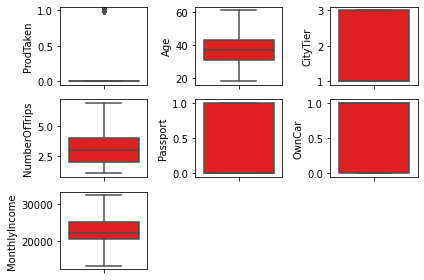

```python
features = num
for i in range(0, len(features)):
    plt.subplot(3,len(features)/2, i+1)
    sns.boxplot(y=df[features[i]], color='red', orient='v')
    plt.tight_layout()
```

## Feature Selection

Based on EDA, we see that there are no features that are highly correlated with each other (redundant). Therefore we decided to use all the features to see the performance results, except for the CustomerID which only contains a unique customer number and has no effect on the target. Feature reduction will be carried out if the results of the matrix or performance obtained are not optimal.

```python
# Drop feature unused
df.drop(columns=['CustomerID'],inplace = True)
```

## Feature Encoding

```python
cats = ['TypeofContact', 'Occupation', 'ProductPitched', 'MaritalStatus', 'Designation', 'Gender']
```

```python
for col in cats:
    print(f'''Value count column {col}:''')
    print(df[col].value_counts())
    print()
```

```
Value count column TypeofContact:
Self Enquiry       3335
Company Invited    1391
Name: TypeofContact, dtype: int64

Value count column Occupation:
Salaried          2287
Small Business    2012
Large Business     425
Free Lancer          2
Name: Occupation, dtype: int64

Value count column ProductPitched:
Basic           1817
Deluxe          1683
Standard         740
Super Deluxe     300
King             186
Name: ProductPitched, dtype: int64

Value count column MaritalStatus:
Married     2263
Single      1547
Divorced     916
Name: MaritalStatus, dtype: int64

Value count column Designation:
Executive         1817
Manager           1683
Senior Manager     740
AVP                300
VP                 186
Name: Designation, dtype: int64

Value count column Gender:
male      2833
female    1893
Name: Gender, dtype: int64
```

Non-ordinal feature:

TypeofContact, Occupation, MaritalStatus, and Gender. encoded using One hot encoding.

Ordinal feature:

ProductPitched and Designation. encoded using label encoding.

```python
# One hot encoding
for cat in ['TypeofContact', 'Occupation', 'MaritalStatus', 'Gender']:
    onehots = pd.get_dummies(df[cat], prefix=cat)
    df = df.join(onehots)
```

```python
# Label encoding
mapping_ProductPitched = {
    'Basic' : 0,
    'Standard' : 1,
    'Deluxe' : 2,
    'Super Deluxe' : 3,
    'King' : 4
}

mapping_Designation = {
    'Executive' : 0,
    'Manager' : 1,
    'Senior Manager' : 2,
    'AVP' : 3,
    'VP' : 4
}

df['ProductPitched'] = df['ProductPitched'].map(mapping_ProductPitched)
df['Designation'] = df['Designation'].map(mapping_Designation)
```

- Remove outdated columns after feature encoding

```python
df = df.drop(columns= ['TypeofContact', 'Occupation', 'MaritalStatus', 'Gender'])
```

```python
df.info()
```

```
<class 'pandas.core.frame.DataFrame'>
Int64Index: 4726 entries, 0 to 4887
Data columns (total 26 columns):
 #   Column                         Non-Null Count  Dtype
---  ------                         --------------  -----
 0   ProdTaken                      4726 non-null   int64
 1   Age                            4726 non-null   float64
 2   CityTier                       4726 non-null   int64
 3   DurationOfPitch                4726 non-null   float64
 4   NumberOfPersonVisiting         4726 non-null   int64
 5   NumberOfFollowups              4726 non-null   float64
 6   ProductPitched                 4726 non-null   int64
 7   PreferredPropertyStar          4726 non-null   float64
 8   NumberOfTrips                  4726 non-null   float64
 9   Passport                       4726 non-null   int64
```

[output cut: 18 more lines]

## Split Dataset

```python
X = df.drop(columns=['ProdTaken'])
y = df['ProdTaken'] # target / label
```

Split to train 70% and test 30%.

```python
#Splitting the data into Train and Test
from sklearn.model_selection import train_test_split
X_train, X_test, y_train, y_test = train_test_split(X, y, test_size = 0.3, random_state = 42)
```

## Feature Scaling

Scaling the features using Standard Scaler after the split test and train data is done to ensure that no information is leaked about the mean and median to the train data. Scaling is also carried out on the test data so that we can test and evaluate whether the model can be generalized again.

```python
from sklearn.preprocessing import StandardScaler
sc = StandardScaler()
X_train = pd.DataFrame(sc.fit_transform(X_train), columns = X.columns)
X_test = pd.DataFrame(sc.transform(X_test), columns = X.columns)
```

## Handling Imbalance Data

```python
print("Amount of data in data train\n",pd.Series(y_train).value_counts())
print("Amount of data in data train\n",pd.Series(y_test).value_counts())
```

```
Amount of data in data train
 0    2658
1     650
Name: ProdTaken, dtype: int64
Amount of data in data train
 0    1172
1     246
Name: ProdTaken, dtype: int64
```

The data train has an unbalanced proportion, therefore it is necessary to use the SMOTE for Imbalanced Classification technique so that the data can train from the same proportion between the target feature (took package or not)

```python
#handle imbalance data train
from imblearn import under_sampling, over_sampling
X_over_SMOTE, y_over_SMOTE = over_sampling.SMOTE(1).fit_resample(X_train, y_train)

print('SMOTE')
print(pd.Series(y_over_SMOTE).value_counts())
```

```
SMOTE
0    2658
1    2658
Name: ProdTaken, dtype: int64
```

# Tuning with Grid Search CV

Once we have the previously balanced train data, the primary evaluation matrix can use recall but we also consider the precision value to be a secondary matrix with the threshold for the precision matrix >= 0.5. This is following our objective, that not wanting a large False Negative Rate (FNR) value or customers who want to buy vacation packages but are considered not to want to buy.

Function Initiation:

```python
from sklearn.metrics import accuracy_score, precision_score, recall_score, f1_score, roc_auc_score

def eval_classification(model):
    y_pred = model.predict(X_test)
    y_pred_train = model.predict(X_over_SMOTE)
    y_pred_proba = model.predict_proba(X_test)
    y_pred_proba_train = model.predict_proba(X_over_SMOTE)

    print("Accuracy (Train Set): %.2f" % accuracy_score(y_over_SMOTE, y_pred_train))
    print("Accuracy (Test Set): %.2f" % accuracy_score(y_test, y_pred))
    print("Precision (Train Set): %.2f" % precision_score(y_over_SMOTE, y_pred_train))
    print("Precision (Test Set): %.2f" % precision_score(y_test, y_pred))
    print("Recall (Train Set): %.2f" % recall_score(y_over_SMOTE, y_pred_train))
    print("Recall (Test Set): %.2f" % recall_score(y_test, y_pred))
    print("F1-Score (Train Set): %.2f" % f1_score(y_over_SMOTE, y_pred_train))
    print("F1-Score (Test Set): %.2f" % f1_score(y_test, y_pred))
    print("AUC (test-proba): %.2f" % roc_auc_score(y_test, y_pred_proba[:, 1]))
    print("AUC (train-proba): %.2f" % roc_auc_score(y_over_SMOTE, y_pred_proba_train[:, 1]))

def show_best_hyperparameter(model):
    print(model.best_estimator_.get_params())
```

## Logistic Regression

```python
# List of hyperparameter
penalty = ['l2','l1','elasticnet']
C = [0.0001, 0.001, 0.002] # Inverse of regularization strength; smaller values specify stronger regularization.
solver = ['liblinear', 'newton-cg','lbfgs']
multi_class= ['multinomial']
hyperparameters = dict(penalty=penalty, C=C, solver=solver, multi_class=multi_class)

# Initiation model
logres = LogisticRegression(random_state=42) # Init Logres dengan Gridsearch, cross validation = 5
logreg_grid = GridSearchCV(logres, hyperparameters, cv=5, scoring='recall')

# Fitting Model & Evaluation
logreg_grid.fit(X_over_SMOTE, y_over_SMOTE)
y_pred = logreg_grid.predict(X_test)
eval_classification(logreg_grid)
```

```
Accuracy (Train Set): 0.76
Accuracy (Test Set): 0.75
Precision (Train Set): 0.76
Precision (Test Set): 0.39
Recall (Train Set): 0.77
Recall (Test Set): 0.73
F1-Score (Train Set): 0.76
F1-Score (Test Set): 0.50
AUC (test-proba): 0.80
AUC (train-proba): 0.83
```

See changes C hyperparameters in score on tuning parameters:

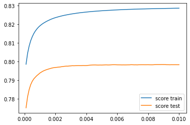

```python
values = [float(x) for x in np.linspace(0.0001, 0.01, num=100)]

train_score = []
test_score = []

for x in values:
    model = LogisticRegression(C=x)
    model.fit(X_over_SMOTE, y_over_SMOTE)

    #eval test
    y_pred_proba = model.predict_proba(X_test)
    auc_test = roc_auc_score(y_test, y_pred_proba[:,1])
    test_score.append(auc_test)

    #eval train
    y_pred_proba_train = model.predict_proba(X_over_SMOTE)
    auc_train = roc_auc_score(y_over_SMOTE, y_pred_proba_train[:,1])
    train_score.append(auc_train)

plt.title('C hyperparameters')
plt.plot(values, train_score, label='score train')
plt.plot(values, test_score, label='score test')
plt.legend()
plt.show()
```

```python
show_best_hyperparameter(logreg_grid)
```

```
{'C': 0.002, 'class_weight': None, 'dual': False, 'fit_intercept': True, 'intercept_scaling': 1, 'l1_ratio': None, 'max_iter': 100, 'multi_class': 'multinomial', 'n_jobs': None, 'penalty': 'l2', 'random_state': 42, 'solver': 'newton-cg', 'tol': 0.0001, 'verbose': 0, 'warm_start': False}
```

```python
logreg_grid.best_score_
```

```
0.7656238052759016
```

```python
lr_tuned = LogisticRegression(random_state=42,
                              C=0.001,
                              penalty='l2',
                              solver='newton-cg',
                              multi_class='multinomial'
                              ).fit(X_over_SMOTE, y_over_SMOTE)
eval_classification(lr_tuned)
```

```
Accuracy (Train Set): 0.76
Accuracy (Test Set): 0.75
Precision (Train Set): 0.76
Precision (Test Set): 0.38
Recall (Train Set): 0.77
Recall (Test Set): 0.72
F1-Score (Train Set): 0.76
F1-Score (Test Set): 0.50
AUC (test-proba): 0.80
AUC (train-proba): 0.82
```

## Decision Tree

```python
# List of hyperparameter
param_grid = {
    'max_features': ['auto', 'sqrt'],
    'max_depth' : [2,4,6,7,8],
    'min_samples_split' : [2, 5],
    'min_samples_leaf' : [1, 2]
}

# Initiation model
dtc=DecisionTreeClassifier(random_state=42)
dtc_grid = GridSearchCV(estimator=dtc, param_grid=param_grid, cv= 5, scoring='recall')

# Fitting Model & Evaluation
dtc_grid.fit(X_over_SMOTE, y_over_SMOTE)
y_pred = dtc_grid.predict(X_test)
eval_classification(dtc_grid)
```

```
Accuracy (Train Set): 0.86
Accuracy (Test Set): 0.79
Precision (Train Set): 0.86
Precision (Test Set): 0.42
Recall (Train Set): 0.87
Recall (Test Set): 0.61
F1-Score (Train Set): 0.86
F1-Score (Test Set): 0.50
AUC (test-proba): 0.76
AUC (train-proba): 0.94
```

See changes in score on hyperparameter max_depth, min_samples_split and min_samples_leaf:

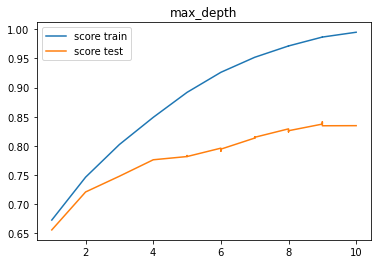

```python
values = max_depth = [int(x) for x in np.linspace(1, 10, num = 50)] # max_depth

train_score = []
test_score = []

for x in values:
    model = DecisionTreeClassifier(max_depth=x)
    model.fit(X_over_SMOTE, y_over_SMOTE)

    #eval test
    y_pred_proba = model.predict_proba(X_test)
    auc_test = roc_auc_score(y_test, y_pred_proba[:,1])
    test_score.append(auc_test)

    #eval train
    y_pred_proba_train = model.predict_proba(X_over_SMOTE)
    auc_train = roc_auc_score(y_over_SMOTE, y_pred_proba_train[:,1])
    train_score.append(auc_train)

plt.title('max_depth')
plt.plot(values, train_score, label='score train')
plt.plot(values, test_score, label='score test')
plt.legend()
plt.show()
```

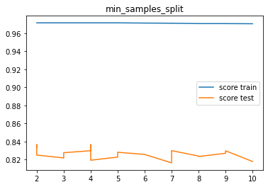

```python
values = [int(x) for x in np.linspace(start = 2, stop = 10, num = 20)] # min_samples_split

train_score = []
test_score = []

for x in values:
    model = DecisionTreeClassifier(max_depth=8, min_samples_split=x )
    model.fit(X_over_SMOTE, y_over_SMOTE)

    #eval test
    y_pred_proba = model.predict_proba(X_test)
    auc_test = roc_auc_score(y_test, y_pred_proba[:,1])
    test_score.append(auc_test)

    #eval train
    y_pred_proba_train = model.predict_proba(X_over_SMOTE)
    auc_train = roc_auc_score(y_over_SMOTE, y_pred_proba_train[:,1])
    train_score.append(auc_train)

plt.title('min_samples_split')
plt.plot(values, train_score, label='score train')
plt.plot(values, test_score, label='score test')
plt.legend()
plt.show()
```

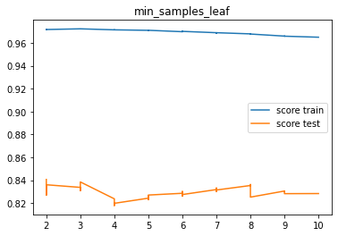

```python
values = [int(x) for x in np.linspace(start = 2, stop = 10, num = 40)] # min_samples_leaf

train_score = []
test_score = []

for x in values:
    model = DecisionTreeClassifier(max_depth=8, min_samples_split=4, min_samples_leaf=x )
    model.fit(X_over_SMOTE, y_over_SMOTE)

    #eval test
    y_pred_proba = model.predict_proba(X_test)
    auc_test = roc_auc_score(y_test, y_pred_proba[:,1])
    test_score.append(auc_test)

    #eval train
    y_pred_proba_train = model.predict_proba(X_over_SMOTE)
    auc_train = roc_auc_score(y_over_SMOTE, y_pred_proba_train[:,1])
    train_score.append(auc_train)

plt.title('min_samples_leaf')
plt.plot(values, train_score, label='score train')
plt.plot(values, test_score, label='score test')
plt.legend()
plt.show()
```

```python
show_best_hyperparameter(dtc_grid)
```

```
{'ccp_alpha': 0.0, 'class_weight': None, 'criterion': 'gini', 'max_depth': 8, 'max_features': 'auto', 'max_leaf_nodes': None, 'min_impurity_decrease': 0.0, 'min_samples_leaf': 1, 'min_samples_split': 5, 'min_weight_fraction_leaf': 0.0, 'random_state': 42, 'splitter': 'best'}
```

```python
dtc_grid.best_score_
```

```
0.7953804001529247
```

```python
dt_tuned = DecisionTreeClassifier(random_state=42,
                                   max_depth=3,
                                   min_samples_split=5,
                                   min_samples_leaf= 1,
                                   max_features='auto',
                                   criterion='gini').fit(X_over_SMOTE, y_over_SMOTE)

eval_classification(dt_tuned)
```

```
Accuracy (Train Set): 0.72
Accuracy (Test Set): 0.72
Precision (Train Set): 0.72
Precision (Test Set): 0.34
Recall (Train Set): 0.72
Recall (Test Set): 0.64
F1-Score (Train Set): 0.72
F1-Score (Test Set): 0.44
AUC (test-proba): 0.74
AUC (train-proba): 0.78
```

## Random Forest

```python
# List of hyperparameter
param_grid = {
    'max_depth' : [2,4,6,7,8],
    'min_samples_split' : [2, 5, 7, 10],
    'min_samples_leaf' : [1, 2, 5],
    'n_estimators': [50, 100, 110, 120],
    'max_features': ['auto', 'sqrt', 'log2'],
    'criterion' : ['gini', 'entropy']
}

# Initiation model
rfc=RandomForestClassifier(random_state=42)
rfc_grid = GridSearchCV(estimator=rfc, param_grid=param_grid, cv= 5, scoring='recall')

# Fitting Model & Evaluation
rfc_grid.fit(X_over_SMOTE, y_over_SMOTE)
y_pred = rfc_grid.predict(X_test)
eval_classification(rfc_grid)
```

```
Accuracy (Train Set): 0.94
Accuracy (Test Set): 0.86
Precision (Train Set): 0.95
Precision (Test Set): 0.59
Recall (Train Set): 0.94
Recall (Test Set): 0.59
F1-Score (Train Set): 0.94
F1-Score (Test Set): 0.59
AUC (test-proba): 0.86
AUC (train-proba): 0.99
```

See changes in score on hyperparameter n_estimators, max_depth, min_samples_split and min_samples_leaf:

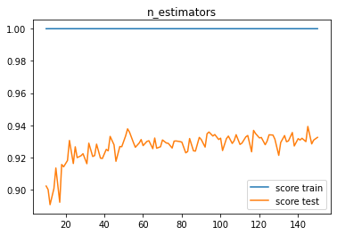

```python
values = [int(x) for x in np.linspace(start = 10, stop = 150, num = 100)] # n_estimators

train_score = []
test_score = []

for x in values:
    model = RandomForestClassifier(n_estimators=x)
    model.fit(X_over_SMOTE, y_over_SMOTE)

    #eval test
    y_pred_proba = model.predict_proba(X_test)
    auc_test = roc_auc_score(y_test, y_pred_proba[:,1])
    test_score.append(auc_test)

    #eval train
    y_pred_proba_train = model.predict_proba(X_over_SMOTE)
    auc_train = roc_auc_score(y_over_SMOTE, y_pred_proba_train[:,1])
    train_score.append(auc_train)

plt.title('n_estimators')
plt.plot(values, train_score, label='score train')
plt.plot(values, test_score, label='score test')
plt.legend()
plt.show()
```

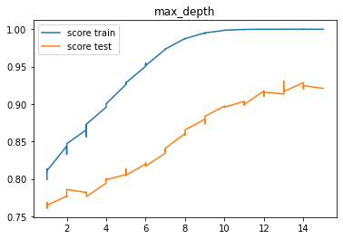

```python
values = max_depth = [int(x) for x in np.linspace(1, 15, num = 50)] # max_depth

train_score = []
test_score = []

for x in values:
    model = RandomForestClassifier(n_estimators=50, max_depth=x)
    model.fit(X_over_SMOTE, y_over_SMOTE)

    #eval test
    y_pred_proba = model.predict_proba(X_test)
    auc_test = roc_auc_score(y_test, y_pred_proba[:,1])
    test_score.append(auc_test)

    #eval train
    y_pred_proba_train = model.predict_proba(X_over_SMOTE)
    auc_train = roc_auc_score(y_over_SMOTE, y_pred_proba_train[:,1])
    train_score.append(auc_train)

plt.title('max_depth')
plt.plot(values, train_score, label='score train')
plt.plot(values, test_score, label='score test')
plt.legend()
plt.show()
```

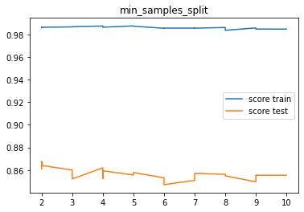

```python
values = [int(x) for x in np.linspace(start = 2, stop = 10, num = 20)] # min_samples_split

train_score = []
test_score = []

for x in values:
    model = RandomForestClassifier(n_estimators=50, max_depth=8, min_samples_split=x )
    model.fit(X_over_SMOTE, y_over_SMOTE)

    #eval test
    y_pred_proba = model.predict_proba(X_test)
    auc_test = roc_auc_score(y_test, y_pred_proba[:,1])
    test_score.append(auc_test)

    #eval train
    y_pred_proba_train = model.predict_proba(X_over_SMOTE)
    auc_train = roc_auc_score(y_over_SMOTE, y_pred_proba_train[:,1])
    train_score.append(auc_train)

plt.title('min_samples_split')
plt.plot(values, train_score, label='score train')
plt.plot(values, test_score, label='score test')
plt.legend()
plt.show()
```

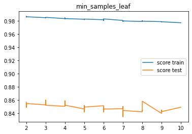

```python
values = [int(x) for x in np.linspace(start = 2, stop = 10, num = 40)] # min_samples_leaf

train_score = []
test_score = []

for x in values:
    model = RandomForestClassifier(n_estimators=50, max_depth=8, min_samples_split=2, min_samples_leaf=x )
    model.fit(X_over_SMOTE, y_over_SMOTE)

    #eval test
    y_pred_proba = model.predict_proba(X_test)
    auc_test = roc_auc_score(y_test, y_pred_proba[:,1])
    test_score.append(auc_test)

    #eval train
    y_pred_proba_train = model.predict_proba(X_over_SMOTE)
    auc_train = roc_auc_score(y_over_SMOTE, y_pred_proba_train[:,1])
    train_score.append(auc_train)

plt.title('min_samples_leaf')
plt.plot(values, train_score, label='score train')
plt.plot(values, test_score, label='score test')
plt.legend()
plt.show()
```

```python
show_best_hyperparameter(rfc_grid)
```

```
{'bootstrap': True, 'ccp_alpha': 0.0, 'class_weight': None, 'criterion': 'gini', 'max_depth': 8, 'max_features': 'auto', 'max_leaf_nodes': None, 'max_samples': None, 'min_impurity_decrease': 0.0, 'min_samples_leaf': 1, 'min_samples_split': 2, 'min_weight_fraction_leaf': 0.0, 'n_estimators': 50, 'n_j…
```

```python
logreg_grid.best_score_
```

```
0.7656238052759016
```

```python
rf_tuned = RandomForestClassifier(random_state=42,
                                   n_estimators=50,
                                   max_depth=2,
                                   criterion='gini',
                                   max_features= 'auto',
                                   min_samples_split=2,
                                   min_samples_leaf=1).fit(X_over_SMOTE, y_over_SMOTE)
eval_classification(rf_tuned)
```

```
Accuracy (Train Set): 0.76
Accuracy (Test Set): 0.76
Precision (Train Set): 0.77
Precision (Test Set): 0.39
Recall (Train Set): 0.73
Recall (Test Set): 0.63
F1-Score (Train Set): 0.75
F1-Score (Test Set): 0.48
AUC (test-proba): 0.78
AUC (train-proba): 0.83
```

## K-Nearest Neighbors

```python
# List of hyperparameter
n_neighbors = list(range(1,40))
p=[1]
algorithm = ['brute']
hyperparameters = dict(n_neighbors=n_neighbors, p=p, algorithm=algorithm)

# Init model
knn = KNeighborsClassifier()
knn_grid = GridSearchCV(knn, hyperparameters, cv=5, scoring='recall')

# Fit Model & Evaluasi
knn_grid.fit(X_over_SMOTE,y_over_SMOTE)
y_pred = knn_grid.predict(X_test)
eval_classification(knn_grid)
```

```
Accuracy (Train Set): 1.00
Accuracy (Test Set): 0.92
Precision (Train Set): 1.00
Precision (Test Set): 0.75
Recall (Train Set): 1.00
Recall (Test Set): 0.79
F1-Score (Train Set): 1.00
F1-Score (Test Set): 0.77
AUC (test-proba): 0.87
AUC (train-proba): 1.00
```

See changes in score on hyperparameter n_neighbors:

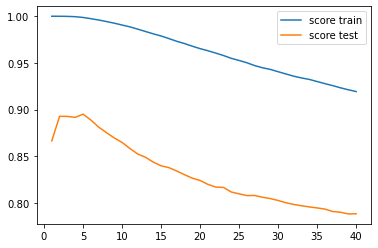

```python
values = [int(x) for x in np.linspace(1, 40, num=100)]

train_score = []
test_score = []

from sklearn.neighbors import KNeighborsClassifier
for x in values:
    model = KNeighborsClassifier(n_neighbors=x)
    model.fit(X_over_SMOTE, y_over_SMOTE)

    #eval test
    y_pred_proba = model.predict_proba(X_test)
    auc_test = roc_auc_score(y_test, y_pred_proba[:,1])
    test_score.append(auc_test)

    #eval test
    y_pred_proba_train = model.predict_proba(X_over_SMOTE)
    auc_train = roc_auc_score(y_over_SMOTE, y_pred_proba_train[:,1])
    train_score.append(auc_train)

plt.plot(values, train_score, label='score train')
plt.plot(values, test_score, label='score test')
plt.legend()
plt.show()
```

```python
show_best_hyperparameter(knn_grid)
```

```
{'algorithm': 'brute', 'leaf_size': 30, 'metric': 'minkowski', 'metric_params': None, 'n_jobs': None, 'n_neighbors': 1, 'p': 1, 'weights': 'uniform'}
```

```python
knn_grid.best_score_
```

```
0.9973670050833299
```

```python
knn_tuned = KNeighborsClassifier(n_neighbors =5,
                               p=1,
                               leaf_size=30,
                               weights='uniform',
                               algorithm = 'brute').fit(X_over_SMOTE, y_over_SMOTE)
eval_classification(knn_tuned)
```

```
Accuracy (Train Set): 0.96
Accuracy (Test Set): 0.86
Precision (Train Set): 0.93
Precision (Test Set): 0.58
Recall (Train Set): 1.00
Recall (Test Set): 0.80
F1-Score (Train Set): 0.96
F1-Score (Test Set): 0.67
AUC (test-proba): 0.91
AUC (train-proba): 1.00
```

## Adaboost

```python
# List of hyperparameter
param_grid = {
    'learning_rate': [0.001, 0.01],
    'n_estimators': [20, 60, 80],
    'algorithm' : ['SAMME.R', 'SAMME']
}

# Init model
ab = AdaBoostClassifier(random_state=42)
ab_grid = GridSearchCV(ab, param_grid, cv=5, scoring='recall')

# Predict & Evaluation
ab_grid.fit(X_over_SMOTE,y_over_SMOTE)
y_pred = ab_grid.predict(X_test)
eval_classification(ab_grid)
```

```
Accuracy (Train Set): 0.74
Accuracy (Test Set): 0.76
Precision (Train Set): 0.76
Precision (Test Set): 0.38
Recall (Train Set): 0.71
Recall (Test Set): 0.64
F1-Score (Train Set): 0.74
F1-Score (Test Set): 0.48
AUC (test-proba): 0.76
AUC (train-proba): 0.78
```

See changes in score on hyperparameter n_estimators, learning_rate:

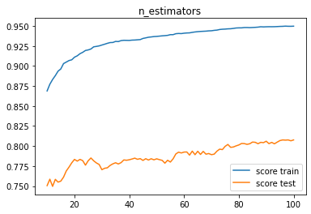

```python
values = [int(x) for x in np.linspace(start = 10, stop = 100, num = 100)] # n_estimators

train_scores = []
test_scores = []

for x in values:
    model = AdaBoostClassifier(n_estimators=x)
    model.fit(X_over_SMOTE,y_over_SMOTE)

    #eval train
    y_pred__train_proba = model.predict_proba(X_over_SMOTE)
    train_auc = roc_auc_score(y_over_SMOTE, y_pred__train_proba[:,1])
    train_scores.append(train_auc)

    #eval test
    y_pred_proba = model.predict_proba(X_test)
    test_auc = roc_auc_score(y_test, y_pred_proba[:,1])
    test_scores.append(test_auc)

plt.title('n_estimators')
plt.plot(values, train_scores, label='score train')
plt.plot(values, test_scores, label='score test')
plt.legend()
plt.show()
```

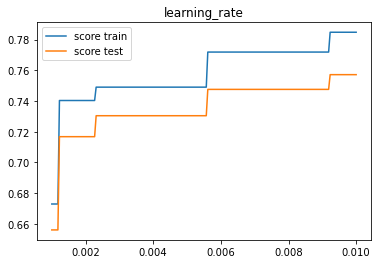

```python
values = [float(x) for x in np.linspace(start = 0.001, stop = 0.01, num = 200)] # learning_rate

train_scores = []
test_scores = []

for x in values:
    model = AdaBoostClassifier(n_estimators=80, learning_rate=x)
    model.fit(X_over_SMOTE,y_over_SMOTE)

    #eval train
    y_pred__train_proba = model.predict_proba(X_over_SMOTE)
    train_auc = roc_auc_score(y_over_SMOTE, y_pred__train_proba[:,1])
    train_scores.append(train_auc)

    #eval test
    y_pred_proba = model.predict_proba(X_test)
    test_auc = roc_auc_score(y_test, y_pred_proba[:,1])
    test_scores.append(test_auc)

plt.title('learning_rate')
plt.plot(values, train_scores, label='score train')
plt.plot(values, test_scores, label='score test')
plt.legend()
plt.show()
```

```python
show_best_hyperparameter(ab_grid)
```

```
{'algorithm': 'SAMME.R', 'base_estimator': None, 'learning_rate': 0.01, 'n_estimators': 80, 'random_state': 42}
```

```python
ab_grid.best_score_
```

```
0.7272538691361171
```

```python
ab_tuned = AdaBoostClassifier(random_state=42,
                               n_estimators=80,
                               learning_rate=0.009,
                               algorithm = 'SAMME.R').fit(X_over_SMOTE, y_over_SMOTE)
eval_classification(ab_tuned)
```

```
Accuracy (Train Set): 0.71
Accuracy (Test Set): 0.69
Precision (Train Set): 0.70
Precision (Test Set): 0.32
Recall (Train Set): 0.74
Recall (Test Set): 0.70
F1-Score (Train Set): 0.72
F1-Score (Test Set): 0.44
AUC (test-proba): 0.75
AUC (train-proba): 0.77
```

## XGBoost

```python
from xgboost import XGBClassifier
xg = XGBClassifier(random_state=42)
xg.fit(X_over_SMOTE, y_over_SMOTE)

eval_classification(xg)
```

```
[08:29:21] WARNING: C:/Users/Administrator/workspace/xgboost-win64_release_1.5.1/src/learner.cc:1115: Starting in XGBoost 1.3.0, the default evaluation metric used with the objective 'binary:logistic' was changed from 'error' to 'logloss'. Explicitly set eval_metric if you'd like to restore the old …
Accuracy (Train Set): 1.00
Accuracy (Test Set): 0.92
Precision (Train Set): 1.00
Precision (Test Set): 0.83
Recall (Train Set): 1.00
Recall (Test Set): 0.67
F1-Score (Train Set): 1.00
F1-Score (Test Set): 0.74
AUC (test-proba): 0.92
AUC (train-proba): 1.00
```

See changes in score on hyperparameter n_estimators, learning_rate:

```python
xgb.set_config(verbosity=0)
```

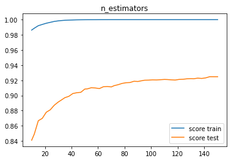

```python
values = [int(x) for x in np.linspace(start = 10, stop = 150, num = 50)] # n_estimators

train_scores = []
test_scores = []

for x in values:
    model = XGBClassifier(n_estimators=x)
    model.fit(X_over_SMOTE,y_over_SMOTE)

    #eval train
    y_pred__train_proba = model.predict_proba(X_over_SMOTE)
    train_auc = roc_auc_score(y_over_SMOTE, y_pred__train_proba[:,1])
    train_scores.append(train_auc)

    #eval test
    y_pred_proba = model.predict_proba(X_test)
    test_auc = roc_auc_score(y_test, y_pred_proba[:,1])
    test_scores.append(test_auc)

plt.title('n_estimators')
plt.plot(values, train_scores, label='score train')
plt.plot(values, test_scores, label='score test')
plt.legend()
plt.show()
```

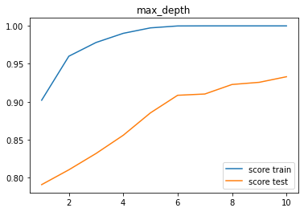

```python
values = [int(x) for x in np.linspace(start = 1, stop = 10, num = 50)] # max_depth

train_scores = []
test_scores = []

for x in values:
    model = XGBClassifier(n_estimators=50, max_depth=x)
    model.fit(X_over_SMOTE,y_over_SMOTE)

    #eval train
    y_pred__train_proba = model.predict_proba(X_over_SMOTE)
    train_auc = roc_auc_score(y_over_SMOTE, y_pred__train_proba[:,1])
    train_scores.append(train_auc)

    #eval test
    y_pred_proba = model.predict_proba(X_test)
    test_auc = roc_auc_score(y_test, y_pred_proba[:,1])
    test_scores.append(test_auc)

plt.title('max_depth')
plt.plot(values, train_scores, label='score train')
plt.plot(values, test_scores, label='score test')
plt.legend()
plt.show()
```

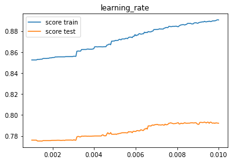

```python
values = [float(x) for x in np.linspace(start = 0.001, stop = 0.01, num = 200)] # learning_rate


train_scores = []
test_scores = []

for x in values:
    model = XGBClassifier(n_estimators=50, max_depth=4, learning_rate=x)
    model.fit(X_over_SMOTE,y_over_SMOTE)

    #eval train
    y_pred__train_proba = model.predict_proba(X_over_SMOTE)
    train_auc = roc_auc_score(y_over_SMOTE, y_pred__train_proba[:,1])
    train_scores.append(train_auc)

    #eval test
    y_pred_proba = model.predict_proba(X_test)
    test_auc = roc_auc_score(y_test, y_pred_proba[:,1])
    test_scores.append(test_auc)

plt.title('learning_rate')
plt.plot(values, train_scores, label='score train')
plt.plot(values, test_scores, label='score test')
plt.legend()
plt.show()
```

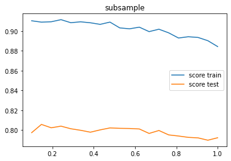

```python
values = [float(x) for x in np.linspace(start = 0.1, stop = 1, num = 20)] # subsample


train_scores = []
test_scores = []

for x in values:
    model = XGBClassifier(n_estimators=50, max_depth=4, learning_rate=0.008, subsample=x )
    model.fit(X_over_SMOTE,y_over_SMOTE)

    #eval train
    y_pred__train_proba = model.predict_proba(X_over_SMOTE)
    train_auc = roc_auc_score(y_over_SMOTE, y_pred__train_proba[:,1])
    train_scores.append(train_auc)

    #eval test
    y_pred_proba = model.predict_proba(X_test)
    test_auc = roc_auc_score(y_test, y_pred_proba[:,1])
    test_scores.append(test_auc)

plt.title('subsample')
plt.plot(values, train_scores, label='score train')
plt.plot(values, test_scores, label='score test')
plt.legend()
plt.show()
```

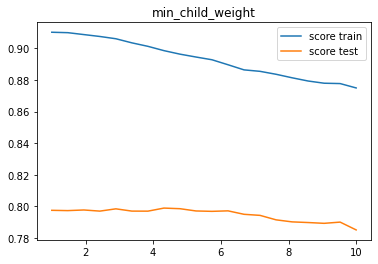

```python
values = [float(x) for x in np.linspace(start = 1, stop = 10, num = 20)] # min_child_weight


train_scores = []
test_scores = []

for x in values:
    model = XGBClassifier(n_estimators=50, max_depth=4, learning_rate=0.008, subsample=0.1, min_child_weight=x )
    model.fit(X_over_SMOTE,y_over_SMOTE)

    #eval train
    y_pred__train_proba = model.predict_proba(X_over_SMOTE)
    train_auc = roc_auc_score(y_over_SMOTE, y_pred__train_proba[:,1])
    train_scores.append(train_auc)

    #eval test
    y_pred_proba = model.predict_proba(X_test)
    test_auc = roc_auc_score(y_test, y_pred_proba[:,1])
    test_scores.append(test_auc)

plt.title('min_child_weight')
plt.plot(values, train_scores, label='score train')
plt.plot(values, test_scores, label='score test')
plt.legend()
plt.show()
```

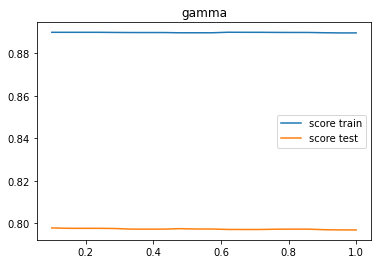

```python
values = [float(x) for x in np.linspace(start = 0.1, stop = 1, num = 20)] # gamma


train_scores = []
test_scores = []

for x in values:
    model = XGBClassifier(n_estimators=50, max_depth=4, learning_rate=0.008, subsample=0.1, min_child_weight=6, gamma=x )
    model.fit(X_over_SMOTE,y_over_SMOTE)

    #eval train
    y_pred__train_proba = model.predict_proba(X_over_SMOTE)
    train_auc = roc_auc_score(y_over_SMOTE, y_pred__train_proba[:,1])
    train_scores.append(train_auc)

    #eval test
    y_pred_proba = model.predict_proba(X_test)
    test_auc = roc_auc_score(y_test, y_pred_proba[:,1])
    test_scores.append(test_auc)

plt.title('gamma')
plt.plot(values, train_scores, label='score train')
plt.plot(values, test_scores, label='score test')
plt.legend()
plt.show()
```

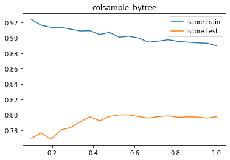

```python
values = [float(x) for x in np.linspace(start = 0.1, stop = 1, num = 20)] # colsample_bytree


train_scores = []
test_scores = []

for x in values:
    model = XGBClassifier(n_estimators=50, max_depth=4, learning_rate=0.008, subsample=0.1, min_child_weight=6, gamma=0.5, colsample_bytree=x )
    model.fit(X_over_SMOTE,y_over_SMOTE)

    #eval train
    y_pred__train_proba = model.predict_proba(X_over_SMOTE)
    train_auc = roc_auc_score(y_over_SMOTE, y_pred__train_proba[:,1])
    train_scores.append(train_auc)

    #eval test
    y_pred_proba = model.predict_proba(X_test)
    test_auc = roc_auc_score(y_test, y_pred_proba[:,1])
    test_scores.append(test_auc)

plt.title('colsample_bytree')
plt.plot(values, train_scores, label='score train')
plt.plot(values, test_scores, label='score test')
plt.legend()
plt.show()
```

```python
clf_xgb_tuned = xgb.XGBClassifier(Missing=None,
                            seed=42,
                            learning_rate = 0.007,
                            n_estimators= 80,
                            max_depth=2,
                            gamma=0.5,
                            subsample=0.1,
                            colsample_bytree=0.7,
                            objective= 'binary:logistic',
                            tree_method='approx',
                            min_child_weight=6,
                            scale_pos_weight=1.5,
                            eta=0.3,
                            reg_lambda=0.06)

clf_xgb_tuned.fit(X_over_SMOTE,
            y_over_SMOTE,
            verbose=True,
            early_stopping_rounds=10,
            eval_metric='auc',
            eval_set=[(X_test, y_test)])
```

```
XGBClassifier(Missing=None, base_score=0.5, booster='gbtree',
              colsample_bylevel=1, colsample_bynode=1, colsample_bytree=0.7,
              enable_categorical=False, eta=0.3, gamma=0.5, gpu_id=-1,
              importance_type=None, interaction_constraints='',
              learning_rate=0.007, max_delta_step=0, max_depth=2,
              min_child_weight=6, missing=nan, monotone_constraints='()',
              n_estimators=80, n_jobs=4, num_parallel_tree=1, predictor='auto',
              random_state=42, reg_alpha=0, reg_lambda=0.06,
              scale_pos_weight=1.5, seed=42, subsample=0.1,
              tree_method='approx', validate_parameters=1, ...)
```

```python
eval_classification(clf_xgb_tuned)
```

```
Accuracy (Train Set): 0.70
Accuracy (Test Set): 0.57
Precision (Train Set): 0.65
Precision (Test Set): 0.27
Recall (Train Set): 0.88
Recall (Test Set): 0.82
F1-Score (Train Set): 0.74
F1-Score (Test Set): 0.40
AUC (test-proba): 0.77
AUC (train-proba): 0.83
```

# Define Model

```python
models_dict = {}
```

```python
models_dict["Logistic Regression"] = LogisticRegression(random_state = 42,
                                                        C = 0.001,
                                                        penalty = 'l2',
                                                        solver='newton-cg',
                                                        multi_class='multinomial')
models_dict["Decision Tree"] = DecisionTreeClassifier(random_state = 42,
                                                      max_depth = 3,
                                                      max_features = 'auto',
                                                      min_samples_leaf = 1,
                                                      min_samples_split = 5,
                                                      criterion='gini')
models_dict["Random Forest"] = RandomForestClassifier(random_state = 42,
                                                      max_depth = 2,
                                                      max_features = 'auto',
                                                      min_samples_leaf = 1,
                                                      min_samples_split = 2,
                                                      n_estimators = 50,
                                                      criterion='gini')
models_dict["KNearest Neighbors"] = KNeighborsClassifier(n_neighbors =3,
                                                         p=1,
                                                         leaf_size=30,
                                                         weights='uniform',
                                                         algorithm = 'brute')
models_dict["AdaBoost"] = AdaBoostClassifier(random_state=42,
                                             n_estimators=80,
                                             learning_rate=0.009,
                                             algorithm = 'SAMME.R')
models_dict["XGBoost"] = XGBClassifier(Missing=None,
                                            seed=42,
                                            learning_rate = 0.007,
                                            n_estimators= 80,
                                            max_depth=2,
                                            gamma=0.5,
                                            subsample=0.1,
                                            colsample_bytree=0.7,
                                            objective= 'binary:logistic',
                                            tree_method='approx',
                                            min_child_weight=6,
                                            scale_pos_weight=1.5,
                                            eta=0.3,
                                            reg_lambda=0.06)
```

# Model Training

```python
for model_name, model in models_dict.items():
    print(f"Training model {model_name}")
    %time model.fit(X_over_SMOTE,y_over_SMOTE)
```

```
Training model Logistic Regression
Wall time: 512 ms
Training model Decision Tree
Wall time: 90.1 ms
Training model Random Forest
Wall time: 178 ms
Training model KNearest Neighbors
Wall time: 14.3 ms
Training model AdaBoost
Wall time: 463 ms
Training model XGBoost
Wall time: 580 ms
```

## Feature Importance

**Logistic Regression**

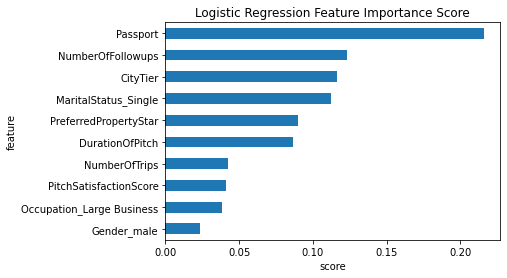

```python
feat_importances = pd.Series(models_dict["Logistic Regression"].coef_[0], index=X.columns)
ax = feat_importances.nlargest(10).plot(kind='barh')
ax.invert_yaxis()
plt.xlabel('score')
plt.ylabel('feature')
plt.title('Logistic Regression Feature Importance Score')
plt.show()
```

```python
# for tree based model
def feature_importance(model, name):
    feat_importances = pd.Series(model.feature_importances_, index=X.columns)
    ax = feat_importances.nlargest(10).plot(kind='barh')
    ax.invert_yaxis()
    plt.xlabel('score')
    plt.ylabel('feature')
    plt.title((name) + ' Feature Importance Score ')
```

**Decision Tree**

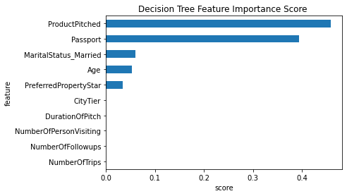

```python
feature_importance(models_dict["Decision Tree"], 'Decision Tree')
plt.show()
```

**Random Forest**

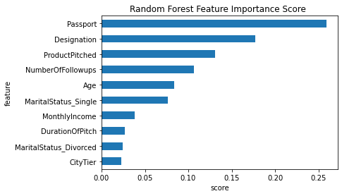

```python
feature_importance(models_dict["Random Forest"], 'Random Forest')
plt.show()
```

**KNearest Neighbors**

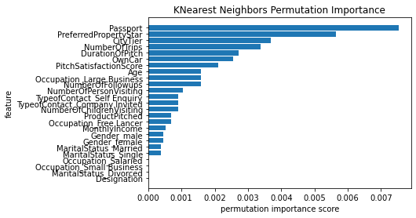

```python
perm_importance = permutation_importance(models_dict["KNearest Neighbors"], X_over_SMOTE,y_over_SMOTE, scoring = "recall")

feature_names = X.columns.tolist()
features = np.array(feature_names)

sorted_idx = perm_importance.importances_mean.argsort()

plt.barh(features[sorted_idx], perm_importance.importances_mean[sorted_idx])
plt.xlabel('permutation importance score')
plt.ylabel('feature')
plt.title('KNearest Neighbors Permutation Importance')
plt.show()
```

**AdaBoost**

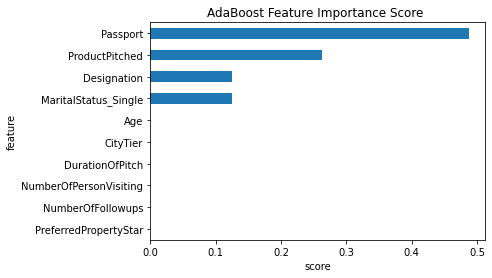

```python
feature_importance(models_dict["AdaBoost"], 'AdaBoost')
plt.show()
```

**XGBoost**

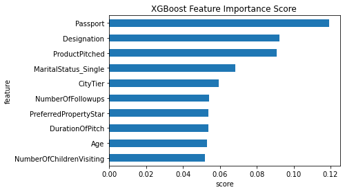

```python
feature_importance(models_dict["XGBoost"], 'XGBoost')
plt.show()
```

## Cross Validation Score

Previously, we have handled imbalanced data using over SMOTE technique. So that it also adjusts to the intended objective, we use recall as the primary matrix and consider precision as a secondary matrix with a threshold >=0.5.

```python
def display_score(scores):
    '''
    function to display cross validation mean and std.
    '''
    print(f"Scores: {scores}")
    print(f"Scores mean: {scores.mean()}")
    print(f"Scores Standar Deviation: {scores.std()}")
```

```python
# create list to store cv scores
scores_cv = []

for model_name, model in models_dict.items():
    print(f"Cross Validation Scores of {model_name}")
    scores = cross_val_score(model, X_over_SMOTE,y_over_SMOTE, scoring = 'recall', cv = 5)
    scores_cv.append(scores)
    display_score(scores)
    print("\n")
```

```
Cross Validation Scores of Logistic Regression
Scores: [0.7556391  0.78154426 0.78154426 0.77631579 0.72180451]
Scores mean: 0.763369582147459
Scores Standar Deviation: 0.022872067408355144


Cross Validation Scores of Decision Tree
Scores: [0.66165414 0.76647834 0.72504708 0.73120301 0.70676692]
Scores mean: 0.7182298967758378
Scores Standar Deviation: 0.03427799533969174


Cross Validation Scores of Random Forest
Scores: [0.61842105 0.72316384 0.78531073 0.78947368 0.70488722]
Scores mean: 0.724251306231681
Scores Standar Deviation: 0.06254343360004604


Cross Validation Scores of KNearest Neighbors
Scores: [0.98308271 1.         1.         0.9943609  1.        ]
Scores mean: 0.9954887218045112
Scores Standar Deviation: 0.006576261535539796


Cross Validation Scores of AdaBoost
Scores: [0.65977444 0.7306968  0.5819209  0.59962406 0.70488722]
Scores mean: 0.6553806833467851
Scores Standar Deviation: 0.05770244268724126


Cross Validation Scores of XGBoost
Scores: [0.83082707 0.89642185 0.91148776 0.91541353 0.85526316]
Scores mean: 0.8818826727836541
Scores Standar Deviation: 0.03324888178999843
```

# Model Evaluation

## Confusion Matrix

**Logistic Regression**

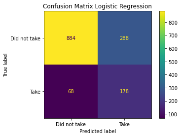

```python
plot_confusion_matrix(models_dict["Logistic Regression"], X_test, y_test, values_format='d', display_labels=['Did not take', 'Take'])
plt.title("Confusion Matrix Logistic Regression")
```

**Decision Tree**

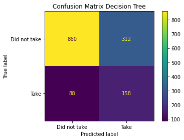

```python
plot_confusion_matrix(models_dict["Decision Tree"], X_test, y_test, values_format='d', display_labels=['Did not take', 'Take'])
plt.title("Confusion Matrix Decision Tree")
```

**Random Forest**

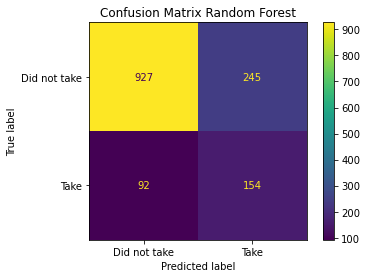

```python
plot_confusion_matrix(models_dict["Random Forest"], X_test, y_test, values_format='d', display_labels=['Did not take', 'Take'])
plt.title("Confusion Matrix Random Forest")
```

**KNearest Neighbors**

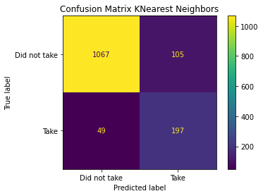

```python
plot_confusion_matrix(models_dict["KNearest Neighbors"], X_test, y_test, values_format='d', display_labels=['Did not take', 'Take'])
plt.title("Confusion Matrix KNearest Neighbors")
```

**AdaBoost**

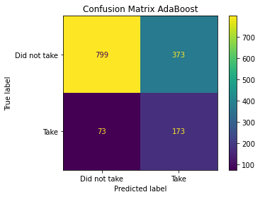

```python
plot_confusion_matrix(models_dict["AdaBoost"], X_test, y_test, values_format='d', display_labels=['Did not take', 'Take'])
plt.title("Confusion Matrix AdaBoost")
```

**XGBoost**

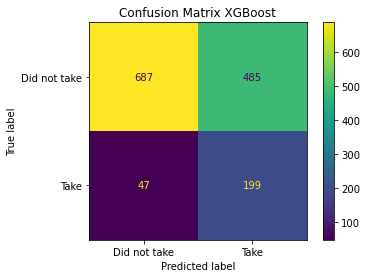

```python
plot_confusion_matrix(models_dict["XGBoost"], X_test, y_test, values_format='d', display_labels=['Did not take', 'Take'])
plt.title("Confusion Matrix XGBoost")
```

## Evaluation

```python
# create list to store prediciton results
train_prediction_results = []
test_prediction_results = []

train_val_time_elapsed = []

for model_name, model in models_dict.items():
    tstart = time.time()
    print(f"Model on {model_name}")
    # predict
    model_pred_test = model.predict(X_test)
    test_prediction_results.append(model_pred_test)

    # append result to list
    model_pred_train = model.predict(X_over_SMOTE)
    train_prediction_results.append(model_pred_train)

    tfinish = time.time()
    time_elapsed = round((tfinish - tstart)*1000, 2)
    train_val_time_elapsed.append(time_elapsed)
    print(f"elapsed time: {time_elapsed} ms")
```

```
Model on Logistic Regression
elapsed time: 402.18 ms
Model on Decision Tree
elapsed time: 28.1 ms
Model on Random Forest
elapsed time: 104.99 ms
Model on KNearest Neighbors
elapsed time: 3348.02 ms
Model on AdaBoost
elapsed time: 367.91 ms
Model on XGBoost
elapsed time: 272.65 ms
```

```python
# create list to append evaluation metrics train
precision_train = []
recall_train = []
accuracy_train = []
confusion_m_train = []
c_report_train = []

# calculate error train
for y_pred in train_prediction_results:
    precision_train.append(precision_score(y_over_SMOTE, y_pred))
    recall_train.append(recall_score(y_over_SMOTE, y_pred))
    accuracy_train.append(accuracy_score(y_over_SMOTE, y_pred))
    confusion_m_train.append(confusion_matrix(y_over_SMOTE, y_pred))
    c_report_train.append(classification_report(y_over_SMOTE, y_pred))

# create list to append evaluation metrics train
precision_test = []
recall_test = []
accuracy_test = []
confusion_m_test = []
c_report_test = []

# calculate error train
for y_pred in test_prediction_results:
    precision_test.append(precision_score(y_test, y_pred))
    recall_test.append(recall_score(y_test, y_pred))
    accuracy_test.append(accuracy_score(y_test, y_pred))
    confusion_m_test.append(confusion_matrix(y_test, y_pred))
    c_report_test.append(classification_report(y_test, y_pred))
```

```python
models_name = list(models_dict.keys())
```

```python
# create dataframe for model performances
eval_dict = {
    'model':models_dict.keys(),
    'Recall_test': recall_test,
    'Recall_train': recall_train,
    'Precision_train': precision_train,
    'Accuracy_train': accuracy_train,
    'Time_Elapsed': train_val_time_elapsed
}
df_results = pd.DataFrame(data=eval_dict)
df_results = df_results.set_index("model")
```

```python
df_results.sort_values(['Recall_test', 'Recall_train','Precision_train'], ascending = False)
```

| model | Recall_test | Recall_train | Precision_train | Accuracy_train | Time_Elapsed |
| --- | --- | --- | --- | --- | --- |
| XGBoost | 0.808943 | 0.876975 | 0.676436 | 0.728743 | 272.65 |
| KNearest Neighbors | 0.800813 | 0.999624 | 0.969001 | 0.983822 | 3348.02 |
| Logistic Regression | 0.723577 | 0.769375 | 0.756287 | 0.760722 | 402.18 |
| AdaBoost | 0.703252 | 0.744545 | 0.697322 | 0.710685 | 367.91 |
| Decision Tree | 0.642276 | 0.717457 | 0.720438 | 0.719526 | 28.10 |
| Random Forest | 0.626016 | 0.725357 | 0.772436 | 0.755831 | 104.99 |

## Shap Value XGboost

```python
# create list to store prediciton results
train_prediction_results = []
test_prediction_results = []

train_val_time_elapsed = []

for model_name, model in models_dict.items():
    tstart = time.time()
    print(f"Model on {model_name}")
    # predict x val
    model_pred_test = model.predict(X_test)
    test_prediction_results.append(model_pred_test)

    # append result to list
    model_pred_train = model.predict(X_over_SMOTE)
    train_prediction_results.append(model_pred_train)

    tfinish = time.time()
    time_elapsed = round((tfinish - tstart)*1000, 2)
    train_val_time_elapsed.append(time_elapsed)
    print(f"elapsed time: {time_elapsed} ms")
```

```
Model on Logistic Regression
elapsed time: 346.83 ms
Model on Decision Tree
elapsed time: 38.11 ms
Model on Random Forest
elapsed time: 141.26 ms
Model on KNearest Neighbors
elapsed time: 1653.3 ms
Model on AdaBoost
elapsed time: 348.2 ms
Model on XGBoost
elapsed time: 359.89 ms
```

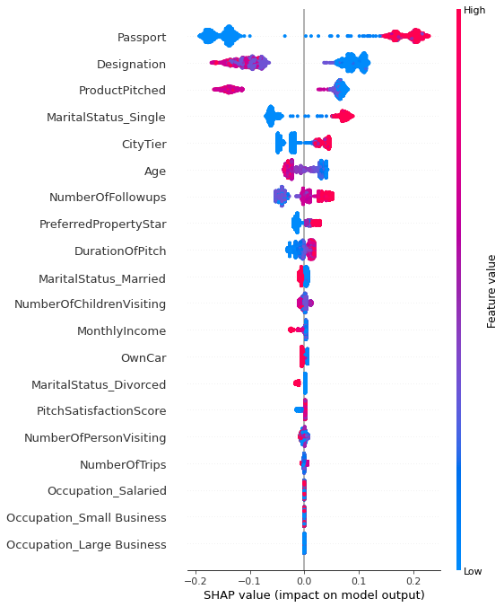

```python
import shap
explainer = shap.Explainer(models_dict["XGBoost"])
shap_values = explainer(X_over_SMOTE)
shap.summary_plot(shap_values, X_over_SMOTE,show=False)
plt.tight_layout()
plt.savefig('shapvalue.png')
```

So we decided to use the XGBoost model which has the best performance, with the result of the shap value we can see the direction of the relationship between all features and target variables as follows:

- Passport is the most influential feature, people who take vacation packages are people who have more passports, this can be seen through the shape value in the range 0.1-0.2
- Customers with basic positions have a high probability of taking vacation packages. with a range of shape values 0 - 0.1
- Customers who take vacation packages are also those who take basic and standard packages.
- Single customers are more likely to take vacation packages

# Conclusion

## Insights From EDA

**Univariate**

- Column 'Age' has a distribution that is close to normal or symmetrical, it can be seen from the picture and the skew value is close to 0.5 (0.41).
- Columns 'DurationOfPitch' and 'MonthlyIncome' have a positive skew (skew to the right) i.e. more concentrated on the left and a long tail on the right side, the skew results also show their respective values are 1.84 and 1.7, respectively.
- Other columns are not given much attention because among them are ordinal and nominal type columns whose format is made in numeric form so that it still needs to be done at the preprocessing stage for Feature Encoding.
- The Self Inquiry category of the 'TypeofContact' column has more proportion than the Company Invited category.
- In the 'Occupation' column, most users come from the Salaried category, while in the Free Lancer category there are almost none.
- Users in the 'Gender' column are dominated by Male.
- In the 'ProductPitched' column the most categories are Basic, then the number is decreasing in the Deluxe to King categories.
- In the 'MaritalStatus' column, the number of users in the Married category is the most compared to other categories.
- Users who are included in the Executive category in the 'Designation' column ranks the most followed by the Manager, Senior Manager, AVP, and VP categories.

**Bivariate**

- The age distribution of customers who pick up or no pick up the package has almost the same symmetric distribution. While the duration of the sales force making offers there is also no significant difference of the distribution, which is symmetrical to the right. It same for the monthly income column, the slope distribution is more symmetrical to the right for customers who take the package or not.
- The result of the frequency that has more customers do not take vacation packages, this is in accordance with the problem statement which explains that only 18% of customers take vacation packages for offers that are made randomly so that it is not appropriate in marketing.
- However, the type of customer contact in making an offer with a larger ratio is the company invited.
- The age of customers who took the package or did not have a median value that was not much different, but slightly more of age variation was found among those who did not take the vacation package.
- The duration of the officer in providing the offer is longer found in customers who take the vacation package, it was described either through the median or average value, although the maximum duration is greater for those who do not take the vacation package, this outlier needs to be re-examined. In addition, the duration of offering at the 75% percentile has two times more customers took the vacation package.
- The monthly income range is greater for customers are not take vacation package, this can be seen through the ptp and std values, but both the mean and median values do not look much different.
- the number of trips there is no significant difference between those who take the package or not.

**Multivariate**

- No feature has a strong correlation with the target (>0.7).
- There are several features to consider, namely 'Passport' (0.23), 'CityTier' (0.11), 'NumberOfFollowups' (0.13), 'Age' (-0.18), and 'MonthlyIncome' (-0.14) because it has a higher correlation value than other features.
- The correlation between features is quite large in the 'MonthlyIncome' feature with 'Age' which has a correlation value of 0.45. The feature 'NumberOfChildrenVisiting' with 'NumberOfPersonVisiting' has a correlation value of 0.61. However, both of them still cannot be said to be redundant because the correlation value is still < 0.7.

## Model Analysis

From a total of 246 customers who took vacation packages, as many as 199 could be predicted correctly. we have reached the expected performance 80%.

**Evaluation**

So we decided to use the XGBoost model which has the best performance, with the result of the shap value we can see the direction of the relationship between all features and target variables as follows:

- Passport is the most influential feature, people who take vacation packages are people who have more passports, this can be seen through the shape value in the range 0.1-0.2
- Customers with basic positions have a high probability of taking vacation packages. with a range of shape values 0 - 0.1
- Customers who take vacation packages are also those who take basic and standard packages.
- Single customers are more likely to take vacation packages

```python
# create list to append evaluation metrics train
precision_train = []
recall_train = []
accuracy_train = []
confusion_m_train = []
c_report_train = []

# calculate error train
for y_pred in train_prediction_results:
    precision_train.append(precision_score(y_over_SMOTE, y_pred))
    recall_train.append(recall_score(y_over_SMOTE, y_pred))
    accuracy_train.append(accuracy_score(y_over_SMOTE, y_pred))
    confusion_m_train.append(confusion_matrix(y_over_SMOTE, y_pred))
    c_report_train.append(classification_report(y_over_SMOTE, y_pred))

# create list to append evaluation metrics test
precision_test = []
recall_test = []
accuracy_test = []
confusion_m_test = []
c_report_test = []

# calculate test
for y_pred in test_prediction_results:
    precision_train.append(precision_score(y_test, y_pred))
    recall_test.append(recall_score(y_test, y_pred))
    accuracy_test.append(accuracy_score(y_test, y_pred))
    confusion_m_test.append(confusion_matrix(y_test, y_pred))
    c_report_test.append(classification_report(y_test, y_pred))
```

```python
# save models name to list for later
models_name = list(models_dict.keys())
```

```python
# create dataframe for model performances
eval_dict = {
    'model':models_dict.keys(),
    'Recall_train': recall_train,
    'Recall_test': recall_test,
    'Precision_train': precision_train,
    'Accuracy_train' : accuracy_train,
    'Time_Elapsed': train_val_time_elapsed
}
df_results = pd.DataFrame(data=eval_dict)
df_results = df_results.set_index("model")
```

```python
df_results.sort_values(['Recall_train', 'Precision_train', 'Accuracy_train'], ascending = False)
```

[output not shown]